# Covid-19 and university student life: Evidence from a self-assessment survey

| Name | SNR | ANR |
| --- | --- | --- |
| Lucrezia Lo Sordo | 2052020 | u323530 |
| Yingshu Deng | 2000506 | u940324 |

## Abstract

Covid-19 crisis has been changing many aspects of individuals' social life globally with the limitation of group gatherings, economic downturns, and the nervousness caused by the fear of getting the virus. We focus our study on a specific group of people - univerisity students - in order to investigate the impact of Covid-19 crisis on the self-assessed studying motivation, group project performance, exam performance, feeling of loneliess, and financial stress, by conducting an online survey. Our results show that the pandemic significantly influences students' studying motivation, feeling of loneliness, and financial stress. Furthermore, we concentrate this research on a subgroup - students in Dutch universities - and we found evidence that the Covid-19 crisis significantly decreases the self-assessed studying movation, group project performance, and increases the feeling of loneliness of the students in Dutch universities.

## Research questions

In this assignment our aim is to answer the following 5 research questions related to students' life during the Covid-19 crisis:

1. Does the Covid-19 crisis affect the university students' self-assessed **studying motivation** ?
2. Does the Covid-19 crisis affect the university students' self-assessed **groupwork performance**?
3. Does the Covid-19 crisis affect the university students' self-assessed **exam performance**?
4. Does the Covid-19 crisis affect the univeristy students' self-assessed **loneliness** ?
5. Does the Covid-19 crisis affect the university students' self-assessed **financial stress**?

## Motivation

Covid-19 crisis has impacted many aspects of the societies, and some might be even profound. Dealing with univerity students, the lockdown prevents face-to-face teaching lessons, and exams are mostly online. In addition, the limitation about the maximum number of people in a group (maximum 2 people in the Netherlands) impedes face-to-face debate, which might reduces the efficiency of group projects' discussions. The lockdown measurements could have psychological impact on students as well. Lastly, many countries are going through economic downturn during this period. For example, the 27 countries of the European Union (EU) suffered from -11.4 % recession in the second quarter of 2020, that is when the Covid-19 was most severe (Eurostat, 2020). The economic downturn could potentially influence the financial stress of univerity students, because they might lose their source of income (i.e. from part-time jobs).

Some studies have already investigated the effects of Covid-19 on university students. In the US, Aucejo et al. (2020) have conducted a survey among 1,500 undergraduate students at Arizona State University in April 2020. They found that 13% of students have delayed graduation, 40% lost a job or an internship, and 29% expect to earn less at the age of 35. Moreover, they pointed out that the effects of Covid-19 pandemic have been highly heterogeneous among university students: in fact, the effect on delayed graduation is 55% more pronounced for lower-income students than higher-income ones. In addition, according to the SMaRteN study (2020), 66% of the 4,000 doctoral candidates who answered the survey, are worried about their future, while 70% of the respondents are facing financial stress. Furthermore, Ambreen and Utsav collected the responses of 500 Indian students, and they found that the 70% is stressed about their studies, and almost 80% of students are not satisfied with online education.

Following this path, we are interested to further investigate the impact of the pandemic on students' self-assessed studying motivation, performance, feeling of loneliness, and financial stress. These factors could potentially impact the long-term development of university students, such as applying post-graduate schools, future earnings, and satisfaction of their future careers.

## Data

In this section, we first describe our dataset, and then explain the data cleaning steps. Lastly, we present the statistical methods we use to analyze it.

#### Data source and dataset

First of all, we created a survey with Google Survey in order to address our 5 research questions. The link below contains the Google Spreadsheet with the original data collected.

[Students and Covid-19 Survey](https://docs.google.com/spreadsheets/d/1p77PHIsSuE4f0QkomA20jMcaZWQO972X7xLpuaPSDzc/edit#gid=449154092).

This survey has been completed during the first week of January 2021 by 135 university students. It contains 13 questions about respondents' socio-demographic characteristics: gender, nationality, second nationality, domicile, relationship status, household composition, the attending level of education, major, second major, their university location, their monthly net income before the Covid-19 pandemic, monthly net income after this event, and whether they receive any students' finance or not. Then, we asked students their motivation, group performance, exam performance, loneliness, and financial stress both before and after the Covid-19 pandemic. Respondents were instructed to rank these 5 variables from 1 to 7, with 1 that means "I rank this variable very low", and 7 which stands for "I rank this variable very high". For example: "How do you rank your motivation before the Covid-19 pandemic?". If the respondent's answer is 1, it means that this person believes her motivation was very low before the pandemic. The table below summarizes the variables' names, the corresponding questions we asked students, and the possible response categories.

| Variable name | Survey's question | Response category |
| --- | --- | --- |
| Gender | Please indicate your gender | Female, Male, Other |
| Nationality | Which is your country of origin (nationality)? | Open answer |
| Second_nationality | What is your second nationality (if applies)? | Open answer |
| Domicile | In which country did you stay (the most) during 2020? | Open answer |
| Relationship_status | What is your relationship status? | Single, In a relationship, Engaged, Married, Separated/Divorced, Widow(er) |
| Household_composition | Please describe your household composition during 2020 | Alone, With 1 roomate, With several roomates, With my partner, With my parents, With my parents and siblings, With my big family |
| Education | Which is the level of education you are attending? | Bachelor's degree, Master of Science/Master, Phd |
| Major | Which is your major? | Open answer |
| Second_major | Which is your second major (If applies)? | Open answer |
| University_country | In which country is your University located? | Open answer |
| Income_before | Which was your monthly net income before the Covid-19 crisis (on average)? | Open answer |
| Income_after | Which was your monthly net income after the Covid-19 crisis (on average)? | Open answer |
| Student_finance | Do you receive any student finance? If so, how much do you receive per month? | Open answer |
| Motivation_before | How do you rank your study motivation before the corona crisis? | 1-7 |
| Group_before | How do you rank your group project performance before the corona crisis? | 1-7 |
| Exam_before | How do you rank your exam performance before the corona crisis? | 1-7 |
| Loneliness_before | How do you rank your loneliness before the lockdown? | 1-7 |
| Financial_stress_before | How do you rank your financial stress before the lockdown? | 1-7 |
| Motivation_after | How do you rank your study motivation after the corona crisis? | 1-7 |
| Group_after | How do you rank your group project performance after the corona crisis? | 1-7 |
| Exam_after | How do you rank your exam performance after the corona crisis? | 1-7 |
| Loneliness_after | How do you rank your loneliness after the lockdown? | 1-7 |
| Financial_stress_after | How do you rank your financial stress after the lockdown? | 1-7 |

#### Data cleaning

After the data collection, we opened the dataset in Jupiter Notebook, in order to proceed with the data cleaning part. First, we deleted 2 unnecessary columns: "Cronological information" and "Score". These are two columns that Google Survey automatically creates when downloading the results on Google Spreadsheets. Second, we renamed the columns in order to give them shorter and more intuitive names, instead of the entire survey's questions. Third, we removed the Euro currency symbol (€) from Income_before, Income_after, and Student_finance. Fourth, we checked the answers given by students for the open questions, and we grouped together those with the same meaning but that were formulated with different words. For example, for the variable "Income_before", students with no income answered differently, for example "0", "N.A", "no", "no income", "0 income", and more. Therefore, we grouped all of them and we replaced with the number "0". Lastly, we coded as numeric the following variables: Income_before, Income_after, and Student_finance.

#### Data summary

1) Background variables

Before analyzing the dataset, we created frequency tables for the categorical variables, and we performed some descriptive statistics on the numerical ones.

In regard of the variable "Education", 26% of the interviewed students are currently enrolled in a Bachelor of Science, 69% are attending a Master of Science or a Master, and only the 5% a Phd. Moreover, 26% of the students are studying Economics, the 12% Marketing or Management, the 4.4% Accounting or Finance, the 15% Engineering, the 11% Medicine, the 15% Global Governance, the 4.4% Law, the 3% Humanistic subjects, such as Languages or Literature, and the 4.4% is following other fields, for example Music or Enology. Lastly, among these 135 students, the 61.5% is enrolled in an Italian university, the 27.4% in a Dutch one, and only the 0.7% is attending a university that is outside Europe.

2) Main outcome variables

Next, we created 6 tables in order to describe our five outcome variables: each table contains a direct comparison of the number of observations, mean, standard deviation, minumum value, and percentiles of the *pre* and *post*-Covid-19 variables. Students' motivation decreased from 5.7 to 3.7, and group project performance dropped from 5.5 to 4.5, while exam performance fell only of 0.8 points, from 5.7 to 4.9. The increased of loneliness of students during the Covid-19 lockdown is quite remarkable, from 2.5 to 5.1. Moreover, students' financial stress rose from 2.8 to 3.7. Additionally, we showed graphically how the five variables of interest changed through frequency distribution tables.

#### Data analysis (Methodology)

We apply Ordinary Least Squares (OLS) regression models to study the causal impact of Covid-19 on self-assessed outcome variables. Two types of OLS regression models are employed. The models without control variables are written as:

$Y_{i}=\beta_0+\beta_1 Covid_{i}+\epsilon_{i}$

The models with individual background control variables are written as:

$Y_{i}=\beta_0+\beta_1 Covid_{i}+ \beta_2 X_{i} + \epsilon_{i}$

In both equations above, $Y_{i}$ is the self-assessed level of motivation, group project performance, exam performance, loneliness, and financial stress before or during the Covid-19 crisis. $Covid_{i}$ represents whether the observation refers to the pre-Covid period or during the pandemic. The effect of Covid is shown by the coefficient $\beta_1$. In the second equation, $X_{i}$ is a vector of individual background control variables, including gender, nationality, domicile, relationship status, household composition, level of education, major of studying, and the country where the respondent's university is located. $\epsilon_{i}$ is the error term. We compare the results of two types of models for robustness test.

## Main assumptions

In order to assess the causal impact of Covid-19 on students' outcomes, we have to know the students' outcomes with and without the Covid-19 crisis, mathematically, the potential outcome framework is:

$\Delta(Y)_{i}=Y_{i}(Covid19=1)-Y_{i}(Covid19=0)$

The first term on the right hand side stands for the student i' outcomes with Covid-19.The second term on the right hand side is the student i' outcomes in the state without Covid-19, which is unoberserved.

This study is based on two main assumptions:

1) We use students' self-reported outcomes before the Covid-19 crisis as counterfactual to represent students' outcomes without Covid-19.

2) Our results are fully based on the self-assessed survey. Therefore, another assumption is that students report their outcomes and background information correctly. Especially, we expect they have good understanding of our scales of outcome variables.

The limitation of these assumption are discussed in the last section.

## Preview of the answers

In this section, we provide an overview of our main results of the five research questions. We consider 5% as statistic significance.

1. First, we found that Covid-19 crisis significantly decreases the studying motivation of the students. The effect is approximately -2.000 points (out of 7) in the baseline OLS regression. When individual background variables are controlled, the effect is reduced to -1.984 points. However, this is still highly significant.

2. Secondly, we found no significant effect of Covid-19 crisis on the group project performance when individual background variables are controlled in the OLS regression.

3. Thirdly, we found no significant effect of Covid-19 on the exam performance of the students when individual background variables are controlled.

4. Fourthly, we found that Covid-19 significantly increases students' self-assessed loneliness. The effect is about 2.659 points (out of 7) in the baseline OLS regression. If we control for the individual background characteristics, the effect is 2.599 points, and it is still highly significant.

5. Lastly, we found that Covid-19 significantly increases students' financial stress. In the baseline OLS regression, the estimated effect is about 0.859 points (out of 7). When we control for the individual background variables, the estimated effect is 0.925 points.

## Python code

In this section we describe the Python code that we used in order to answer our five research questions. We created sub-sections to make the code easier to understand. Each of them refers to one sub-section of the part called "Data": data cleaning, data summary, and data analysis. Lastly, we report the Python code employed to conduct sensitivity analysis.

#### Data cleaning

The first chunks contains the data cleaning steps. We have already described them in the section "Data cleaning", but we have included a bief description also inside the chunks.

```python
# Import packages
import numpy as np
import pandas as pd
import matplotlib.pyplot as plt
```

```python
# Open the dataset
sheet_id = "1p77PHIsSuE4f0QkomA20jMcaZWQO972X7xLpuaPSDzc"
df = pd.read_csv(f"https://docs.google.com/spreadsheets/d/{sheet_id}/export?format=csv")
```

```python
# Delete unnecessary columns
df = df.drop(columns =["Cronological information", "Score"])
```

```python
# Rename columns
df.columns = ["Motivation_before", "Group_before", "Exam_before", "Loneliness_before", "Financial_stress_before",
              "Motivation_after", "Group_after", "Exam_after", "Loneliness_after", "Financial_stress_after",
             "Income_before", "Income_after", "Student_finance", "Gender", "Nationality", "Second_nationality",
             "Domicile", "Relationship_status", "Household_composition", "Education", "Major", "Second_major",
             "University_country"]
```

```python
# Remove € symbol
df["Income_before"] = df["Income_before"].astype(str).str.replace("€","")
df["Income_after"] = df["Income_after"].astype(str).str.replace("€", "")
df["Student_finance"] = df["Student_finance"].astype(str).str.replace("€", "")
```

```python
# Group together similar response categories
df["Income_before"] = df["Income_before"].replace(["No income", "Non ho reddito ", "-", "//", "N.A",
                                                   "Not your buisness", "X", "0 (I was studying)", "My parents",
                                                  "0, I’m a student", "None", "none", "I hadn't my own income",
                                                  "I don’t have one"], "0")
```

```python
# Group together similar response categories
df["Income_after"] = df["Income_after"].replace(["No income", "Non ho reddito ", "-", "//", "N.A",
                                                   "Not your buisness", "X", "0 (I was studying)", "My parents",
                                                  "0, I’m a student", "None", "none", "I hadn't my own income",
                                                  "I don’t have one", "No income ", "Like above ", "0 (I didn’t work while studying)",
                                                 "0 because I decide to solely focus on my studies. ", "000"], "0")
```

```python
# Group together similar response categories
df["Student_finance"] = df["Student_finance"].replace(["No", "No ", "no", "None", "-", "NO", "Niente",
                                                "none", "I don’t receive any student finance", "Like above ",
                                                "None", "No, my parents helped me and I had savings from having worked",
                                                "X", "N.A", "none ", "Not", "Nothing", "I didn't receive ",
                                                "No student finance"], "0")
```

```python
# Group together similar response categories
df["Nationality"] = df["Nationality"].replace(["Italy ", "Italian", "Italia", "italy", "Italia ", "ITALIAN"], "Italy")
df["Nationality"] = df["Nationality"].replace(["The Netherlands", "Dutch", "Netherlands ", "Nederland"], "Netherlands")
df["Nationality"] = df["Nationality"].replace("German", "Germany")
df["Nationality"] = df["Nationality"].replace(["Portuguese", "Portugal "], "Portugal")
df["Nationality"] = df["Nationality"].replace("French", "France")
df["Nationality"] = df["Nationality"].replace(["American", "America", "United States"], "USA")
df["Nationality"] = df["Nationality"].replace("Chinese ", "China")
df["Nationality"] = df["Nationality"].replace("Spanish", "Spain")
df["Nationality"] = df["Nationality"].replace("Cypriot", "Cypro")
```

```python
# Group together similar response categories
df["Second_nationality"] = df["Second_nationality"].replace("Italy", "Italian")
```

```python
# Group together similar response categories
df["Domicile"] = df["Domicile"].replace(["Italia", "Italy ", "italy", "Rome", "Pompei", "Roma ", "Roma", "ITALY",
                                        "Italia ", "Latina, Italy"], "Italy")
df["Domicile"] = df["Domicile"].replace(["Netherlands ", "The Netherlands", "The Netherlands ",
                                       "Nederland "], "Netherlands")
df["Domicile"] = df["Domicile"].replace(["United States", "America"], "USA")
df["Domicile"] = df["Domicile"].replace("Belgium ", "Belgium")
df["Domicile"] = df["Domicile"].replace(["Germany ", "German"], "Germany")
df["Domicile"] = df["Domicile"].replace(["Lisbon", "Portugal "], "Portugal")
df["Domicile"] = df["Domicile"].replace("U.K.", "UK")
```

```python
# Group together similar response categories
df["Major"] = df["Major"].replace(["Economics ", "Behaviour economics", "Economia", "Econometrics", "Economcis"], "Economics")
df["Major"] = df["Major"].replace(["Finance", "Accounting"], "Accounting and Finance")
df["Major"] = df["Major"].replace(["Supply chain management ", "Marketing Management ", "Marketing", "Marketing Management", "Business administration", "Business Administration ", "Management of aerospace systems for defense",
                                  "Economia & Management", "Strategic Management ", "Strategic Management", "Business Administration", "International Management ",
                                  "International management "], "Management & Marketing")
df["Major"] = df["Major"].replace(["Cyber", "Software Engineer", "Engeneering", "Engeneering ", "Aerospace engeneering",
                                  "Mechanical  engineering", "Mechanical engineering", "Ingegneria meccanica",
                                  "Automation and IT engineering", "Electronics Engineering", "Engineer", "Studente di ingegneria ",
                                  "Nanobiotechnologies", "Pharmaceutical technologies and chemistry", "Engineering "], "Engineering")
df["Major"] = df["Major"].replace(["Dentistry", "Medicine and surgery", "Medicine and Surgery", "Medicina e Chirurgia ",
                                  "Pharmaceutical science", "Scienze Biologiche ", "Biochemistry ", "Midwifery", "Obstetrics "], "Medicine")
df["Major"] = df["Major"].replace(["Law school ", "Law student"], "Law")
df["Major"] = df["Major"].replace(["Political Science", "Global Economic Governance", "International security",
                                  "Global Economic Governance and Public Affairs", "Strategic science",
                                  "International Security ", "International relations ", "Air Force ",
                                  "International Relations"], "Global Governance")
df["Major"] = df["Major"].replace(["Ciclo unico ", ".", "?", "-", "No clue ", "The rector"], "NaN")
df["Major"] = df["Major"].replace(["Asian studies", "Religions and Philosophy", "Languages", "Lettere indirizzo antico"], "Humanistic studies")
df["Major"] = df["Major"].replace(["Football refree", "Enology", "Music", "Environmental Studies", "Architecture "], "Other")
```

```python
# Group together similar response categories
df["University_country"] = df["University_country"].replace(["Italy ", "Italia", "Rome", "Naples, Italy", "ITALY",
                                                             "Roma", "italy", "Verona", "Trento", "Pozzuoli"], "Italy")
df["University_country"] = df["University_country"].replace(["The Netherlands ", "The Netherlands", "Netherlans", "Tilburg", "Netherlands ",
                                                             "Nederland"], "Netherlands")
df["University_country"] = df["University_country"].replace("United Kingdom", "UK")
```

```python
# Convert Income_before, Income_after, and Student_finance to numeric variables
df["Income_before"] = pd.to_numeric(df["Income_before"], errors='coerce')
df["Income_after"] = pd.to_numeric(df["Income_after"], errors='coerce')
df["Student_finance"] = pd.to_numeric(df["Student_finance"], errors='coerce')
```

#### Data summary

In the following 8 chunks, there are the code lines to produce 8 frequency tables, in order to summarize the categorical variables that we will later use for the regression analysis.

```python
# Gender frequency table
pd.crosstab(index=df["Gender"],
                      columns="percentage").apply(lambda r: r/r.sum()).round(decimals=3)
```

| col_0 Gender | percentage |
| --- | --- |
| Female | 0.511 |
| Male | 0.481 |
| Other | 0.007 |

```python
# Nationality frequency table
pd.crosstab(index=df["Nationality"],
                      columns="percentage").apply(lambda r: r/r.sum()).round(decimals=3)
```

| col_0 Nationality | percentage |
| --- | --- |
| Argentina | 0.007 |
| China | 0.015 |
| Croatia | 0.007 |
| Cypro | 0.007 |
| Czech Republic | 0.007 |
| France | 0.022 |
| Germany | 0.030 |
| Ireland | 0.007 |
| Italy | 0.689 |
| Netherlands | 0.104 |
| Poland | 0.007 |
| Portugal | 0.022 |
| Spain | 0.007 |
| Sweden | 0.007 |
| Turkish | 0.022 |
| UK | 0.007 |
| USA | 0.022 |
| Ukraine | 0.007 |

```python
# Domicile frequency table
pd.crosstab(index=df["Domicile"],
                      columns="percentage").apply(lambda r: r/r.sum()).round(decimals=3)
```

| col_0 Domicile | percentage |
| --- | --- |
| Belgium | 0.015 |
| Czech Republic | 0.015 |
| Denmark | 0.015 |
| France | 0.015 |
| Germany | 0.022 |
| Hungary | 0.007 |
| Ireland | 0.007 |
| Italy | 0.615 |
| Netherlands | 0.222 |
| Portugal | 0.022 |
| Sweden | 0.007 |
| UK | 0.015 |
| USA | 0.015 |
| United Arab Emirates | 0.007 |

```python
# Relationship_status frequency table
pd.crosstab(index=df["Relationship_status"],
                      columns="percentage").apply(lambda r: r/r.sum()).round(decimals=3)
```

| col_0 Relationship_status | percentage |
| --- | --- |
| Engaged | 0.052 |
| In a relationship | 0.459 |
| Single | 0.489 |

```python
# Household_composition frequency table
pd.crosstab(index=df["Household_composition"],
                      columns="percentage").apply(lambda r: r/r.sum()).round(decimals=3)
```

| col_0 Household_composition | percentage |
| --- | --- |
| Alone | 0.044 |
| With 1 roomate | 0.126 |
| With my big family | 0.015 |
| With my parents | 0.252 |
| With my parents and sibling(s) | 0.244 |
| With my partner (boyfriend, girlfriend, husband, wife...) | 0.104 |
| With several roomates | 0.215 |

```python
# Education frequency table
pd.crosstab(index=df["Education"],
                      columns="percentage").apply(lambda r: r/r.sum()).round(decimals=3)
```

| col_0 Education | percentage |
| --- | --- |
| Bachelor's Degree | 0.259 |
| Master of Science / Master | 0.689 |
| Phd | 0.052 |

```python
# Major frequency table
pd.crosstab(index=df["Major"],
                      columns="percentage").apply(lambda r: r/r.sum()).round(decimals=3)
```

| col_0 Major | percentage |
| --- | --- |
| Accounting and Finance | 0.044 |
| Economics | 0.259 |
| Engineering | 0.148 |
| Global Governance | 0.148 |
| Humanistic studies | 0.030 |
| Law | 0.044 |
| Management & Marketing | 0.119 |
| Medicine | 0.111 |
| NaN | 0.052 |
| Other | 0.044 |

```python
# University country frequency table
pd.crosstab(index=df["University_country"],
                      columns="percentage").apply(lambda r: r/r.sum()).round(decimals=3)
```

| col_0 University_country | percentage |
| --- | --- |
| Argentina | 0.007 |
| Denmark | 0.015 |
| France | 0.044 |
| Hungary | 0.007 |
| Italy | 0.615 |
| Italy/China | 0.015 |
| Netherlands | 0.274 |
| Switzerland | 0.007 |
| UK | 0.015 |

Next, we proceed with the descriptive statistics part for the numerical variables: specifically, we create 6 tables in order to show how the motivation, group performance, exam performance, feeling of loneliness, financial stress, and income change after the Covid-19 pandemic.

```python
# Descriptive statistics: Motivation
df[["Motivation_before","Motivation_after"]].describe().round(decimals=3)
```

|  | Motivation_before | Motivation_after |
| --- | --- | --- |
| count | 135.000 | 135.000 |
| mean | 5.704 | 3.704 |
| std | 1.127 | 1.881 |
| min | 1.000 | 1.000 |
| 25% | 5.000 | 2.000 |
| 50% | 6.000 | 4.000 |
| 75% | 7.000 | 5.000 |
| max | 7.000 | 7.000 |

```python
# Descriptive statistics: Group project performance
df[["Group_before","Group_after"]].describe().round(decimals=3)
```

|  | Group_before | Group_after |
| --- | --- | --- |
| count | 135.000 | 135.000 |
| mean | 5.511 | 4.459 |
| std | 1.158 | 1.674 |
| min | 1.000 | 1.000 |
| 25% | 5.000 | 3.000 |
| 50% | 6.000 | 5.000 |
| 75% | 6.000 | 6.000 |
| max | 7.000 | 7.000 |

```python
# Descriptive statistics: Exam performance
df[["Exam_before","Exam_after"]].describe().round(decimals=3)
```

|  | Exam_before | Exam_after |
| --- | --- | --- |
| count | 135.000 | 135.000 |
| mean | 5.667 | 4.859 |
| std | 1.015 | 1.527 |
| min | 3.000 | 1.000 |
| 25% | 5.000 | 4.000 |
| 50% | 6.000 | 5.000 |
| 75% | 6.000 | 6.000 |
| max | 7.000 | 7.000 |

```python
# Descriptive statistics: Loneliness
df[["Loneliness_before","Loneliness_after"]].describe().round(decimals=3)
```

|  | Loneliness_before | Loneliness_after |
| --- | --- | --- |
| count | 135.000 | 135.000 |
| mean | 2.452 | 5.111 |
| std | 1.470 | 1.524 |
| min | 1.000 | 1.000 |
| 25% | 1.000 | 4.000 |
| 50% | 2.000 | 5.000 |
| 75% | 3.000 | 6.000 |
| max | 7.000 | 7.000 |

```python
# Descriptive statistics: Financial Stress
df[["Financial_stress_before","Financial_stress_after"]].describe().round(decimals=3)
```

|  | Financial_stress_before | Financial_stress_after |
| --- | --- | --- |
| count | 135.000 | 135.000 |
| mean | 2.837 | 3.696 |
| std | 1.645 | 1.913 |
| min | 1.000 | 1.000 |
| 25% | 2.000 | 2.000 |
| 50% | 2.000 | 4.000 |
| 75% | 4.000 | 5.000 |
| max | 7.000 | 7.000 |

```python
# Descriptive statistics: Income
df[["Income_before","Income_after"]].describe().round(decimals=3)
```

|  | Income_before | Income_after |
| --- | --- | --- |
| count | 135.000 | 135.000 |
| mean | 537.696 | 403.852 |
| std | 688.241 | 574.851 |
| min | 0.000 | 0.000 |
| 25% | 0.000 | 0.000 |
| 50% | 250.000 | 50.000 |
| 75% | 1000.000 | 600.000 |
| max | 3000.000 | 2000.000 |

In the following chunks, we show the frequency distribution of the variables of interest. This is useful in order to see the change clearly.

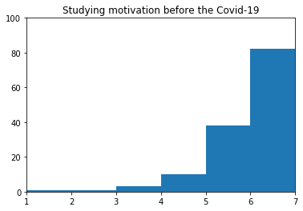

```python
# Frequency distribution graph of Motivation_before
a = np.array(df[["Motivation_before"]])
plt.hist(a, bins = [1,2,3,4,5,6,7])
plt.title("Studying motivation before the Covid-19")
plt.axis([1, 7, 0, 100])
plt.show()
```

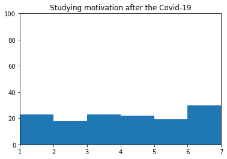

```python
# Frequency distribution graph of Motivation_after
a = np.array(df[["Motivation_after"]])
plt.hist(a, bins = [1,2,3,4,5,6,7])
plt.title("Studying motivation after the Covid-19")
plt.axis([1, 7, 0, 100])
plt.show()
```

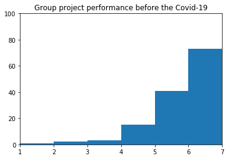

```python
# Frequency distribution graph of Group_before
a = np.array(df[["Group_before"]])
plt.hist(a, bins = [1,2,3,4,5,6,7])
plt.title("Group project performance before the Covid-19")
plt.axis([1, 7, 0, 100])
plt.show()
```

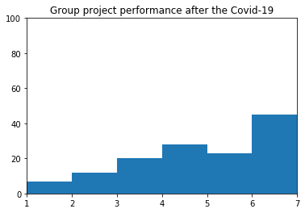

```python
# Frequency distribution graph of Group_after
a = np.array(df[["Group_after"]])
plt.hist(a, bins = [1,2,3,4,5,6,7])
plt.title("Group project performance after the Covid-19")
plt.axis([1, 7, 0, 100])
plt.show()
```

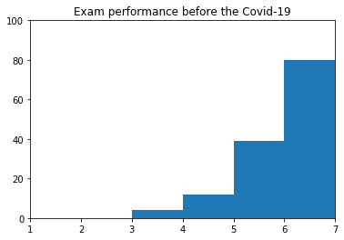

```python
# Frequency distribution graph of Exam_before
a = np.array(df[["Exam_before"]])
plt.hist(a, bins = [1,2,3,4,5,6,7])
plt.title("Exam performance before the Covid-19")
plt.axis([1, 7, 0, 100])
plt.show()
```

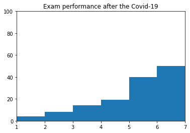

```python
# Frequency distribution graph of Exam_after
a = np.array(df[["Exam_after"]])
plt.hist(a, bins = [1,2,3,4,5,6,7])
plt.title("Exam performance after the Covid-19")
plt.axis([1, 7, 0, 100])
plt.show()
```

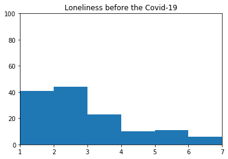

```python
# Frequency distribution graph of Loneliness_before
a = np.array(df[["Loneliness_before"]])
plt.hist(a, bins = [1,2,3,4,5,6,7])
plt.title("Loneliness before the Covid-19")
plt.axis([1, 7, 0, 100])
plt.show()
```

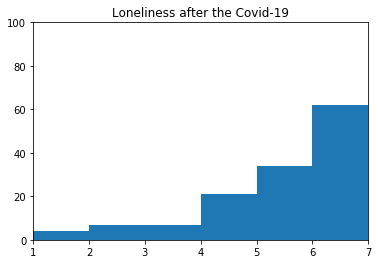

```python
# Frequency distribution graph of Loneliness_after
a = np.array(df[["Loneliness_after"]])
plt.hist(a, bins = [1,2,3,4,5,6,7])
plt.title("Loneliness after the Covid-19")
plt.axis([1, 7, 0, 100])
plt.show()
```

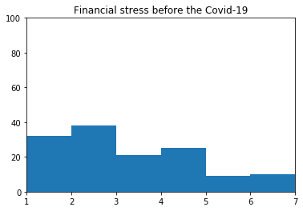

```python
# Frequency distribution graph of Financial_stress_before
a = np.array(df[["Financial_stress_before"]])
plt.hist(a, bins = [1,2,3,4,5,6,7])
plt.title("Financial stress before the Covid-19")
plt.axis([1, 7, 0, 100])
plt.show()
```

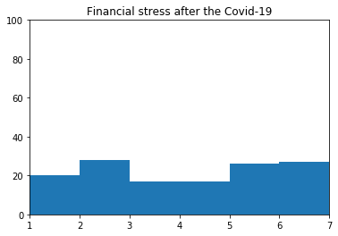

```python
# Frequency distribution graph of Financial_stress_after
a = np.array(df[["Financial_stress_after"]])
plt.hist(a, bins = [1,2,3,4,5,6,7])
plt.title("Financial stress after the Covid-19")
plt.axis([1, 7, 0, 100])
plt.show()
```

#### More data cleaning

Furthermore, before running the regressions, we need to merge together the *pre*-Covid columns with the *post*-Covid ones. For example, we would like to have a dataset in which we have just one column called "Motivation", instead of "Motivation_before" and "Motivation_after". The same hold for: Group, Exam, Loneliness, Financial_stress, and Income. However, we need to create a new column called "Covid" in order to know which observations belong to the *pre*-Covid period and which ones to the *post*-Covid. This new variable should assume the value of "0" for all the *pre*-Covid observations, and "1" for all the *post*-Covid.

In the following chunks, we explain step by step how we did this. First, we created 2 copies of the original dataframe, called respectively: "df_covid_0" and "df_covid_1". However, these two are not exact copies. In fact, both have the socio-demographic characteristics, but df_covid_0 also has the *before* variables, while df_covid_1 has the *after* variables.

```python
# Create a copy of df and name it df_covid_0 (socio-demographic + before-Covid variables)
df_covid_0 = df[["Motivation_before", "Group_before", "Exam_before", "Loneliness_before", "Financial_stress_before",
                 "Income_before", "Student_finance", "Gender", "Nationality", "Second_nationality",
                 "Domicile", "Relationship_status", "Household_composition", "Education", "Major", "Second_major",
                 "University_country"]].copy()

# Create a copy of df and name it df_covid_1 (socio-demographic + after-Covid variables)
df_covid_1 = df[["Motivation_after", "Group_after", "Exam_after", "Loneliness_after", "Financial_stress_after",
             "Income_after", "Student_finance", "Gender", "Nationality", "Second_nationality",
             "Domicile", "Relationship_status", "Household_composition", "Education", "Major", "Second_major",
             "University_country"]].copy()
```

Second, we create a new column called "Covid" in both the dataframes. This variable has the value of "0" for all the observations that are in df_covid_0, and the value of "1" for all the observations that are present in df_covid_1.

```python
# Create the column "Covid" which is 0 for all the observations
df_covid_0['Covid'] = 0

# Create the column "Covid" which is 1 for all the observations
df_covid_1['Covid'] = 1
```

Third, we rename the columns of both the dataframes in order to give them the same names. We want to merge them in the end, therefore this step is necessary.

```python
# Provide the columns of both the df with the same names
df_covid_0.columns = ["Motivation", "Group", "Exam", "Loneliness", "Financial_stress",
                      "Income", "Student_finance", "Gender", "Nationality", "Second_nationality",
                      "Domicile", "Relationship_status", "Household_composition", "Education", "Major", "Second_major",
                      "University_country", "Covid"]

df_covid_1.columns = ["Motivation", "Group", "Exam", "Loneliness", "Financial_stress",
                      "Income", "Student_finance", "Gender", "Nationality", "Second_nationality",
                      "Domicile", "Relationship_status", "Household_composition", "Education", "Major", "Second_major",
                      "University_country", "Covid"]
```

At this point, we have 2 dataframes, df_covid_0 and df_covid_1. These two have the same variables, but the first one has all the *pre*-Covid observations, while the second one has all the *post*_Covid ones. And both have the same socio-demographic characteristics. Therefore, we can merge them now.

```python
# Merge df_covid_0 and df_covid_1
df_total = df_covid_0.append(df_covid_1)
```

#### Data analysis (Methodology)

At this point, we can run the models to test the effect of Covid-19 on our variables of interest: the motivation to study, group projects performance, individual exams performance, loneliness, and financial stress. For each dependent variable, we run one simple OLS regression without any control variable, and then, one regression with the individual background control variables collected.

```python
# Import packages
from sklearn.linear_model import LinearRegression
import statsmodels.formula.api as smf
from scipy import stats
```

```python
# Model 1: Motivation
model1=lm=smf.ols('Motivation~Covid', data=df_total).fit(cov_type='HC1')
model1.summary()
```

OLS Regression Results

| Dep. Variable: | Motivation | R-squared: | 0.295 |
| --- | --- | --- | --- |
| Model: | OLS | Adj. R-squared: | 0.293 |
| Method: | Least Squares | F-statistic: | 112.3 |
| Date: | Fri, 29 Jan 2021 | Prob (F-statistic): | 3.81e-22 |
| Time: | 14:01:04 | Log-Likelihood: | -500.53 |
| No. Observations: | 270 | AIC: | 1005. |
| Df Residuals: | 268 | BIC: | 1012. |
| Df Model: | 1 |  |  |
| Covariance Type: | HC1 |  |  |

|  | coef | std err | z | P>\|z\| | [0.025 | 0.975] |
| --- | --- | --- | --- | --- | --- | --- |
| Intercept | 5.7037 | 0.097 | 58.812 | 0.000 | 5.514 | 5.894 |
| Covid | -2.0000 | 0.189 | -10.598 | 0.000 | -2.370 | -1.630 |

| Omnibus: | 2.013 | Durbin-Watson: | 1.914 |
| --- | --- | --- | --- |
| Prob(Omnibus): | 0.366 | Jarque-Bera (JB): | 1.924 |
| Skew: | -0.131 | Prob(JB): | 0.382 |
| Kurtosis: | 2.680 | Cond. No. | 2.62 |

Warnings:  
[1] Standard Errors are heteroscedasticity robust (HC1)

```python
# Model 2: Motivation with control variables
model2=lm=smf.ols('Motivation~Covid + Gender +Income + Domicile+Nationality+ Relationship_status+ Household_composition+Education+Major+Second_major+University_country+ Student_finance', data=df_total).fit(cov_type='HC1')
model2.summary()
```

OLS Regression Results

| Dep. Variable: | Motivation | R-squared: | 0.695 |
| --- | --- | --- | --- |
| Model: | OLS | Adj. R-squared: | 0.375 |
| Method: | Least Squares | F-statistic: | 1.074e+04 |
| Date: | Fri, 29 Jan 2021 | Prob (F-statistic): | 3.47e-36 |
| Time: | 14:01:05 | Log-Likelihood: | -61.173 |
| No. Observations: | 42 | AIC: | 166.3 |
| Df Residuals: | 20 | BIC: | 204.6 |
| Df Model: | 21 |  |  |
| Covariance Type: | HC1 |  |  |

|  | coef | std err | z | P>\|z\| | [0.025 | 0.975] |
| --- | --- | --- | --- | --- | --- | --- |
| Intercept | 2.0771 | 0.357 | 5.815 | 0.000 | 1.377 | 2.777 |
| Gender[T.Male] | 0.6662 | 0.701 | 0.950 | 0.342 | -0.709 | 2.041 |
| Gender[T.Other] | -2.537e-14 | 1.13e-14 | -2.246 | 0.025 | -4.75e-14 | -3.23e-15 |
| Domicile[T.Czech Republic] | 0.0979 | 0.436 | 0.225 | 0.822 | -0.756 | 0.952 |
| Domicile[T.Denmark] | -2.901e-16 | 1.64e-16 | -1.771 | 0.077 | -6.11e-16 | 3.09e-17 |
| Domicile[T.France] | 5.207e-16 | 4.01e-16 | 1.298 | 0.194 | -2.66e-16 | 1.31e-15 |
| Domicile[T.Germany] | 4.494e-16 | 3.41e-16 | 1.319 | 0.187 | -2.18e-16 | 1.12e-15 |
| Domicile[T.Hungary] | 7.831e-16 | 3.39e-16 | 2.310 | 0.021 | 1.19e-16 | 1.45e-15 |
| Domicile[T.Ireland] | -1.272e-15 | 5.71e-16 | -2.226 | 0.026 | -2.39e-15 | -1.52e-16 |
| Domicile[T.Italy] | -0.1443 | 0.428 | -0.337 | 0.736 | -0.983 | 0.694 |
| Domicile[T.Netherlands] | 1.3212 | 0.439 | 3.009 | 0.003 | 0.460 | 2.182 |
| Domicile[T.Portugal] | 1.5806 | 0.825 | 1.916 | 0.055 | -0.036 | 3.197 |
| Domicile[T.Sweden] | 8.367e-16 | 1.99e-16 | 4.210 | 0.000 | 4.47e-16 | 1.23e-15 |
| Domicile[T.UK] | -0.6527 | 1.053 | -0.620 | 0.535 | -2.716 | 1.410 |
| Domicile[T.USA] | -0.3038 | 0.249 | -1.222 | 0.222 | -0.791 | 0.183 |
| Domicile[T.United Arab Emirates] | 0.1783 | 0.210 | 0.849 | 0.396 | -0.234 | 0.590 |
| Nationality[T.China] | 8.353e-16 | 3.38e-16 | 2.469 | 0.014 | 1.72e-16 | 1.5e-15 |
| Nationality[T.Croatia] | -0.3313 | 0.176 | -1.887 | 0.059 | -0.675 | 0.013 |
| Nationality[T.Cypro] | -2.686e-16 | 1.23e-16 | -2.175 | 0.030 | -5.11e-16 | -2.66e-17 |
| Nationality[T.Czech Republic] | 0.0123 | 0.547 | 0.022 | 0.982 | -1.060 | 1.085 |
| Nationality[T.France] | 1.302e-18 | 7.46e-17 | 0.017 | 0.986 | -1.45e-16 | 1.48e-16 |
| Nationality[T.Germany] | -8.007e-17 | 1.66e-16 | -0.484 | 0.629 | -4.04e-16 | 2.44e-16 |
| Nationality[T.Ireland] | 0 | 0 | nan | nan | 0 | 0 |
| Nationality[T.Italy] | 0.8692 | 0.254 | 3.421 | 0.001 | 0.371 | 1.367 |
| Nationality[T.Netherlands] | 0 | 0 | nan | nan | 0 | 0 |
| Nationality[T.Poland] | 0 | 0 | nan | nan | 0 | 0 |
| Nationality[T.Portugal] | 0 | 0 | nan | nan | 0 | 0 |
| Nationality[T.Spain] | 0 | 0 | nan | nan | 0 | 0 |
| Nationality[T.Sweden] | 0 | 0 | nan | nan | 0 | 0 |
| Nationality[T.Turkish] | 0 | 0 | nan | nan | 0 | 0 |
| Nationality[T.UK] | 0.1783 | 0.210 | 0.849 | 0.396 | -0.234 | 0.590 |
| Nationality[T.USA] | -0.3038 | 0.249 | -1.222 | 0.222 | -0.791 | 0.183 |
| Nationality[T.Ukraine] | 0 | 0 | nan | nan | 0 | 0 |
| Relationship_status[T.In a relationship] | 0.5204 | 0.436 | 1.192 | 0.233 | -0.335 | 1.376 |
| Relationship_status[T.Single] | 0.0692 | 0.373 | 0.186 | 0.853 | -0.661 | 0.799 |
| Household_composition[T.With 1 roomate] | 0.8880 | 0.361 | 2.463 | 0.014 | 0.181 | 1.595 |
| Household_composition[T.With my big family] | 0 | 0 | nan | nan | 0 | 0 |
| Household_composition[T.With my parents] | -0.1691 | 0.499 | -0.339 | 0.735 | -1.147 | 0.809 |
| Household_composition[T.With my parents and sibling(s)] | 0.1776 | 0.553 | 0.321 | 0.748 | -0.907 | 1.262 |
| Household_composition[T.With my partner (boyfriend, girlfriend, husband, wife...)] | 0.9432 | 0.486 | 1.942 | 0.052 | -0.008 | 1.895 |
| Household_composition[T.With several roomates] | 0.2374 | 0.306 | 0.776 | 0.437 | -0.362 | 0.837 |
| Education[T.Master of Science / Master] | 0.9684 | 0.352 | 2.749 | 0.006 | 0.278 | 1.659 |
| Education[T.Phd] | -0.3399 | 0.285 | -1.191 | 0.234 | -0.899 | 0.220 |
| Major[T.Economics] | 0.6463 | 0.285 | 2.267 | 0.023 | 0.088 | 1.205 |
| Major[T.Engineering] | 0.2762 | 0.352 | 0.785 | 0.433 | -0.414 | 0.966 |
| Major[T.Global Governance] | 0.2405 | 0.383 | 0.627 | 0.530 | -0.511 | 0.992 |
| Major[T.Humanistic studies] | 0 | 0 | nan | nan | 0 | 0 |
| Major[T.Law] | 0.0512 | 0.669 | 0.077 | 0.939 | -1.260 | 1.362 |
| Major[T.Management & Marketing] | -0.4611 | 0.528 | -0.873 | 0.383 | -1.496 | 0.574 |
| Major[T.Medicine] | -0.3399 | 0.285 | -1.191 | 0.234 | -0.899 | 0.220 |
| Major[T.Other] | 0.0856 | 0.384 | 0.223 | 0.824 | -0.667 | 0.838 |
| Second_major[T.Biophysics ] | -0.3399 | 0.285 | -1.191 | 0.234 | -0.899 | 0.220 |
| Second_major[T.Control and auditing] | -0.5443 | 0.582 | -0.935 | 0.350 | -1.686 | 0.597 |
| Second_major[T.Economics ] | 0.9776 | 0.305 | 3.208 | 0.001 | 0.380 | 1.575 |
| Second_major[T.Electronics] | 0.4197 | 0.361 | 1.162 | 0.245 | -0.288 | 1.127 |
| Second_major[T.Finance] | 0.0512 | 0.669 | 0.077 | 0.939 | -1.260 | 1.362 |
| Second_major[T.Financial economics] | -0.3313 | 0.176 | -1.887 | 0.059 | -0.675 | 0.013 |
| Second_major[T.International Trade] | 1.6525 | 0.518 | 3.189 | 0.001 | 0.637 | 2.668 |
| Second_major[T.International security ] | 0.0432 | 0.832 | 0.052 | 0.959 | -1.588 | 1.674 |
| Second_major[T.Luxury, Fashion & Made in Italy ] | 0.0832 | 0.320 | 0.260 | 0.795 | -0.543 | 0.710 |
| Second_major[T.Mechatronics] | -0.1436 | 0.471 | -0.305 | 0.760 | -1.066 | 0.779 |
| Second_major[T.Public Affairs] | -1.0791 | 0.531 | -2.031 | 0.042 | -2.121 | -0.038 |
| Second_major[T.Public Affaris] | -0.3038 | 0.249 | -1.222 | 0.222 | -0.791 | 0.183 |
| Second_major[T.Public affairs] | 0.1783 | 0.210 | 0.849 | 0.396 | -0.234 | 0.590 |
| Second_major[T.Strategic science] | 1.4876 | 0.595 | 2.499 | 0.012 | 0.321 | 2.654 |
| University_country[T.Denmark] | 0 | 0 | nan | nan | 0 | 0 |
| University_country[T.France] | -0.0733 | 0.532 | -0.138 | 0.890 | -1.116 | 0.969 |
| University_country[T.Hungary] | 0 | 0 | nan | nan | 0 | 0 |
| University_country[T.Italy] | 1.1601 | 0.345 | 3.366 | 0.001 | 0.485 | 1.836 |
| University_country[T.Italy/China] | 0.0832 | 0.320 | 0.260 | 0.795 | -0.543 | 0.710 |
| University_country[T.Netherlands] | -0.3313 | 0.176 | -1.887 | 0.059 | -0.675 | 0.013 |
| University_country[T.Switzerland] | -0.0742 | 0.443 | -0.168 | 0.867 | -0.942 | 0.794 |
| University_country[T.UK] | -0.3399 | 0.285 | -1.191 | 0.234 | -0.899 | 0.220 |
| Covid | -1.9839 | 0.538 | -3.690 | 0.000 | -3.038 | -0.930 |
| Income | 0.0002 | 0.000 | 0.597 | 0.551 | -0.001 | 0.001 |
| Student_finance | 0.0021 | 0.001 | 1.958 | 0.050 | -1.76e-06 | 0.004 |

| Omnibus: | 1.608 | Durbin-Watson: | 1.516 |
| --- | --- | --- | --- |
| Prob(Omnibus): | 0.447 | Jarque-Bera (JB): | 1.091 |
| Skew: | -0.000 | Prob(JB): | 0.580 |
| Kurtosis: | 2.210 | Cond. No. | 1.23e+16 |

Warnings:  
[1] Standard Errors are heteroscedasticity robust (HC1)  
[2] The input rank is higher than the number of observations.  
[3] The smallest eigenvalue is 1.71e-25. This might indicate that there are  
strong multicollinearity problems or that the design matrix is singular.

```python
# Model 3: Group projects performance
model3=lm=smf.ols('Group~Covid', data=df_total).fit(cov_type='HC1')
model3.summary()
```

OLS Regression Results

| Dep. Variable: | Group | R-squared: | 0.119 |
| --- | --- | --- | --- |
| Model: | OLS | Adj. R-squared: | 0.115 |
| Method: | Least Squares | F-statistic: | 36.05 |
| Date: | Fri, 29 Jan 2021 | Prob (F-statistic): | 6.25e-09 |
| Time: | 14:01:05 | Log-Likelihood: | -480.45 |
| No. Observations: | 270 | AIC: | 964.9 |
| Df Residuals: | 268 | BIC: | 972.1 |
| Df Model: | 1 |  |  |
| Covariance Type: | HC1 |  |  |

|  | coef | std err | z | P>\|z\| | [0.025 | 0.975] |
| --- | --- | --- | --- | --- | --- | --- |
| Intercept | 5.5111 | 0.100 | 55.290 | 0.000 | 5.316 | 5.706 |
| Covid | -1.0519 | 0.175 | -6.004 | 0.000 | -1.395 | -0.708 |

| Omnibus: | 9.586 | Durbin-Watson: | 1.795 |
| --- | --- | --- | --- |
| Prob(Omnibus): | 0.008 | Jarque-Bera (JB): | 10.038 |
| Skew: | -0.471 | Prob(JB): | 0.00661 |
| Kurtosis: | 2.931 | Cond. No. | 2.62 |

Warnings:  
[1] Standard Errors are heteroscedasticity robust (HC1)

```python
# Model 4: Group projects performance with control variables
model4=lm=smf.ols('Group~ Covid+ Gender +Income+Domicile+ Nationality+ Relationship_status+ Household_composition+ Education+Major+Second_major+University_country+Student_finance',data=df_total).fit(cov_type='HC1')
model4.summary()
```

OLS Regression Results

| Dep. Variable: | Group | R-squared: | 0.457 |
| --- | --- | --- | --- |
| Model: | OLS | Adj. R-squared: | -0.113 |
| Method: | Least Squares | F-statistic: | 268.9 |
| Date: | Fri, 29 Jan 2021 | Prob (F-statistic): | 3.37e-20 |
| Time: | 14:01:05 | Log-Likelihood: | -60.923 |
| No. Observations: | 42 | AIC: | 165.8 |
| Df Residuals: | 20 | BIC: | 204.1 |
| Df Model: | 21 |  |  |
| Covariance Type: | HC1 |  |  |

|  | coef | std err | z | P>\|z\| | [0.025 | 0.975] |
| --- | --- | --- | --- | --- | --- | --- |
| Intercept | 1.8714 | 0.353 | 5.301 | 0.000 | 1.180 | 2.563 |
| Gender[T.Male] | 0.9437 | 0.542 | 1.740 | 0.082 | -0.119 | 2.007 |
| Gender[T.Other] | -2.492e-14 | 1.08e-14 | -2.302 | 0.021 | -4.61e-14 | -3.71e-15 |
| Domicile[T.Czech Republic] | 0.3846 | 0.537 | 0.716 | 0.474 | -0.669 | 1.438 |
| Domicile[T.Denmark] | 6.721e-17 | 1.7e-16 | 0.394 | 0.693 | -2.67e-16 | 4.01e-16 |
| Domicile[T.France] | 1.059e-16 | 3.54e-16 | 0.299 | 0.765 | -5.87e-16 | 7.99e-16 |
| Domicile[T.Germany] | 2.222e-16 | 1.95e-16 | 1.138 | 0.255 | -1.6e-16 | 6.05e-16 |
| Domicile[T.Hungary] | -6.575e-17 | 4.36e-16 | -0.151 | 0.880 | -9.21e-16 | 7.89e-16 |
| Domicile[T.Ireland] | 4.126e-17 | 5.7e-16 | 0.072 | 0.942 | -1.08e-15 | 1.16e-15 |
| Domicile[T.Italy] | 0.1112 | 0.417 | 0.267 | 0.790 | -0.706 | 0.928 |
| Domicile[T.Netherlands] | 0.1927 | 0.398 | 0.485 | 0.628 | -0.587 | 0.972 |
| Domicile[T.Portugal] | 0.3376 | 1.027 | 0.329 | 0.742 | -1.675 | 2.350 |
| Domicile[T.Sweden] | 2.105e-16 | 1.48e-16 | 1.419 | 0.156 | -8.03e-17 | 5.01e-16 |
| Domicile[T.UK] | 0.1260 | 0.730 | 0.173 | 0.863 | -1.305 | 1.557 |
| Domicile[T.USA] | 0.1774 | 0.219 | 0.812 | 0.417 | -0.251 | 0.606 |
| Domicile[T.United Arab Emirates] | 0.5418 | 0.336 | 1.610 | 0.107 | -0.118 | 1.201 |
| Nationality[T.China] | 3.255e-16 | 4.19e-16 | 0.777 | 0.437 | -4.95e-16 | 1.15e-15 |
| Nationality[T.Croatia] | 0.0502 | 0.152 | 0.330 | 0.742 | -0.248 | 0.348 |
| Nationality[T.Cypro] | -5.779e-17 | 9.22e-17 | -0.627 | 0.531 | -2.38e-16 | 1.23e-16 |
| Nationality[T.Czech Republic] | 0.5193 | 0.589 | 0.882 | 0.378 | -0.635 | 1.674 |
| Nationality[T.France] | 1.366e-17 | 5.95e-17 | 0.229 | 0.819 | -1.03e-16 | 1.3e-16 |
| Nationality[T.Germany] | -1.23e-17 | 9.62e-17 | -0.128 | 0.898 | -2.01e-16 | 1.76e-16 |
| Nationality[T.Ireland] | 0 | 0 | nan | nan | 0 | 0 |
| Nationality[T.Italy] | 0.4401 | 0.263 | 1.674 | 0.094 | -0.075 | 0.955 |
| Nationality[T.Netherlands] | 0 | 0 | nan | nan | 0 | 0 |
| Nationality[T.Poland] | 0 | 0 | nan | nan | 0 | 0 |
| Nationality[T.Portugal] | 0 | 0 | nan | nan | 0 | 0 |
| Nationality[T.Spain] | 0 | 0 | nan | nan | 0 | 0 |
| Nationality[T.Sweden] | 0 | 0 | nan | nan | 0 | 0 |
| Nationality[T.Turkish] | 0 | 0 | nan | nan | 0 | 0 |
| Nationality[T.UK] | 0.5418 | 0.336 | 1.610 | 0.107 | -0.118 | 1.201 |
| Nationality[T.USA] | 0.1774 | 0.219 | 0.812 | 0.417 | -0.251 | 0.606 |
| Nationality[T.Ukraine] | 0 | 0 | nan | nan | 0 | 0 |
| Relationship_status[T.In a relationship] | 0.7518 | 0.351 | 2.145 | 0.032 | 0.065 | 1.439 |
| Relationship_status[T.Single] | 0.9409 | 0.239 | 3.939 | 0.000 | 0.473 | 1.409 |
| Household_composition[T.With 1 roomate] | 1.0482 | 0.371 | 2.825 | 0.005 | 0.321 | 1.775 |
| Household_composition[T.With my big family] | 0 | 0 | nan | nan | 0 | 0 |
| Household_composition[T.With my parents] | 0.3739 | 0.368 | 1.015 | 0.310 | -0.348 | 1.096 |
| Household_composition[T.With my parents and sibling(s)] | -0.1766 | 0.247 | -0.714 | 0.475 | -0.662 | 0.308 |
| Household_composition[T.With my partner (boyfriend, girlfriend, husband, wife...)] | 0.4904 | 0.477 | 1.028 | 0.304 | -0.444 | 1.425 |
| Household_composition[T.With several roomates] | 0.1355 | 0.403 | 0.336 | 0.737 | -0.655 | 0.926 |
| Education[T.Master of Science / Master] | 1.1331 | 0.305 | 3.717 | 0.000 | 0.536 | 1.731 |
| Education[T.Phd] | 0.0389 | 0.362 | 0.107 | 0.914 | -0.670 | 0.748 |
| Major[T.Economics] | 0.4920 | 0.439 | 1.121 | 0.262 | -0.368 | 1.353 |
| Major[T.Engineering] | -0.2412 | 0.279 | -0.865 | 0.387 | -0.788 | 0.306 |
| Major[T.Global Governance] | 0.4891 | 0.470 | 1.041 | 0.298 | -0.432 | 1.410 |
| Major[T.Humanistic studies] | 0 | 0 | nan | nan | 0 | 0 |
| Major[T.Law] | 0.1112 | 0.322 | 0.345 | 0.730 | -0.520 | 0.742 |
| Major[T.Management & Marketing] | 0.2228 | 0.604 | 0.369 | 0.712 | -0.961 | 1.407 |
| Major[T.Medicine] | 0.0389 | 0.362 | 0.107 | 0.914 | -0.670 | 0.748 |
| Major[T.Other] | -0.1347 | 0.503 | -0.268 | 0.789 | -1.121 | 0.852 |
| Second_major[T.Biophysics ] | 0.0389 | 0.362 | 0.107 | 0.914 | -0.670 | 0.748 |
| Second_major[T.Control and auditing] | 0.3117 | 0.623 | 0.500 | 0.617 | -0.910 | 1.534 |
| Second_major[T.Economics ] | 0.4419 | 0.513 | 0.861 | 0.389 | -0.564 | 1.448 |
| Second_major[T.Electronics] | 0.1463 | 0.208 | 0.702 | 0.483 | -0.262 | 0.555 |
| Second_major[T.Finance] | 0.1112 | 0.322 | 0.345 | 0.730 | -0.520 | 0.742 |
| Second_major[T.Financial economics] | 0.0502 | 0.152 | 0.330 | 0.742 | -0.248 | 0.348 |
| Second_major[T.International Trade] | 0.1425 | 0.427 | 0.333 | 0.739 | -0.695 | 0.980 |
| Second_major[T.International security ] | -0.1989 | 0.272 | -0.731 | 0.465 | -0.732 | 0.335 |
| Second_major[T.Luxury, Fashion & Made in Italy ] | -0.0889 | 0.356 | -0.250 | 0.803 | -0.786 | 0.608 |
| Second_major[T.Mechatronics] | -0.3875 | 0.320 | -1.211 | 0.226 | -1.015 | 0.240 |
| Second_major[T.Public Affairs] | -0.3447 | 0.462 | -0.747 | 0.455 | -1.249 | 0.560 |
| Second_major[T.Public Affaris] | 0.1774 | 0.219 | 0.812 | 0.417 | -0.251 | 0.606 |
| Second_major[T.Public affairs] | 0.5418 | 0.336 | 1.610 | 0.107 | -0.118 | 1.201 |
| Second_major[T.Strategic science] | 0.1787 | 0.568 | 0.315 | 0.753 | -0.935 | 1.292 |
| University_country[T.Denmark] | 0 | 0 | nan | nan | 0 | 0 |
| University_country[T.France] | 0.6332 | 0.560 | 1.130 | 0.259 | -0.465 | 1.732 |
| University_country[T.Hungary] | 0 | 0 | nan | nan | 0 | 0 |
| University_country[T.Italy] | 0.3448 | 0.387 | 0.890 | 0.373 | -0.414 | 1.104 |
| University_country[T.Italy/China] | -0.0889 | 0.356 | -0.250 | 0.803 | -0.786 | 0.608 |
| University_country[T.Netherlands] | 0.0502 | 0.152 | 0.330 | 0.742 | -0.248 | 0.348 |
| University_country[T.Switzerland] | 0.7508 | 0.395 | 1.899 | 0.058 | -0.024 | 1.526 |
| University_country[T.UK] | 0.0389 | 0.362 | 0.107 | 0.914 | -0.670 | 0.748 |
| Covid | -0.7196 | 0.492 | -1.462 | 0.144 | -1.684 | 0.245 |
| Income | -0.0007 | 0.001 | -0.932 | 0.351 | -0.002 | 0.001 |
| Student_finance | 0.0011 | 0.001 | 0.943 | 0.346 | -0.001 | 0.003 |

| Omnibus: | 1.103 | Durbin-Watson: | 2.215 |
| --- | --- | --- | --- |
| Prob(Omnibus): | 0.576 | Jarque-Bera (JB): | 0.900 |
| Skew: | 0.000 | Prob(JB): | 0.638 |
| Kurtosis: | 2.283 | Cond. No. | 1.23e+16 |

Warnings:  
[1] Standard Errors are heteroscedasticity robust (HC1)  
[2] The input rank is higher than the number of observations.  
[3] The smallest eigenvalue is 1.71e-25. This might indicate that there are  
strong multicollinearity problems or that the design matrix is singular.

```python
# Model 5: Exams performance
model5=lm=smf.ols('Exam~Covid',data=df_total).fit(cov_type='HC1')
model5.summary()
```

OLS Regression Results

| Dep. Variable: | Exam | R-squared: | 0.089 |
| --- | --- | --- | --- |
| Model: | OLS | Adj. R-squared: | 0.086 |
| Method: | Least Squares | F-statistic: | 26.19 |
| Date: | Fri, 29 Jan 2021 | Prob (F-statistic): | 5.92e-07 |
| Time: | 14:01:06 | Log-Likelihood: | -452.17 |
| No. Observations: | 270 | AIC: | 908.3 |
| Df Residuals: | 268 | BIC: | 915.5 |
| Df Model: | 1 |  |  |
| Covariance Type: | HC1 |  |  |

|  | coef | std err | z | P>\|z\| | [0.025 | 0.975] |
| --- | --- | --- | --- | --- | --- | --- |
| Intercept | 5.6667 | 0.087 | 64.879 | 0.000 | 5.495 | 5.838 |
| Covid | -0.8074 | 0.158 | -5.117 | 0.000 | -1.117 | -0.498 |

| Omnibus: | 16.887 | Durbin-Watson: | 1.920 |
| --- | --- | --- | --- |
| Prob(Omnibus): | 0.000 | Jarque-Bera (JB): | 18.323 |
| Skew: | -0.627 | Prob(JB): | 0.000105 |
| Kurtosis: | 3.235 | Cond. No. | 2.62 |

Warnings:  
[1] Standard Errors are heteroscedasticity robust (HC1)

```python
# Model 6: Exams performance with control variables
model6=lm=smf.ols('Exam~Covid+Gender+Income+Domicile+Nationality+Relationship_status+ Household_composition+Education+Major+Second_major+University_country+Student_finance',data=df_total).fit(cov_type='HC1')
model6.summary()
```

OLS Regression Results

| Dep. Variable: | Exam | R-squared: | 0.718 |
| --- | --- | --- | --- |
| Model: | OLS | Adj. R-squared: | 0.421 |
| Method: | Least Squares | F-statistic: | 3.313e+04 |
| Date: | Fri, 29 Jan 2021 | Prob (F-statistic): | 4.47e-41 |
| Time: | 14:01:06 | Log-Likelihood: | -42.670 |
| No. Observations: | 42 | AIC: | 129.3 |
| Df Residuals: | 20 | BIC: | 167.6 |
| Df Model: | 21 |  |  |
| Covariance Type: | HC1 |  |  |

|  | coef | std err | z | P>\|z\| | [0.025 | 0.975] |
| --- | --- | --- | --- | --- | --- | --- |
| Intercept | 1.7763 | 0.233 | 7.612 | 0.000 | 1.319 | 2.234 |
| Gender[T.Male] | 0.4266 | 0.329 | 1.296 | 0.195 | -0.219 | 1.072 |
| Gender[T.Other] | -2.581e-14 | 7.06e-15 | -3.654 | 0.000 | -3.96e-14 | -1.2e-14 |
| Domicile[T.Czech Republic] | -0.7975 | 0.237 | -3.358 | 0.001 | -1.263 | -0.332 |
| Domicile[T.Denmark] | -1.327e-16 | 1.06e-16 | -1.256 | 0.209 | -3.4e-16 | 7.43e-17 |
| Domicile[T.France] | -3.435e-17 | 2.29e-16 | -0.150 | 0.881 | -4.84e-16 | 4.15e-16 |
| Domicile[T.Germany] | 9.029e-17 | 1.55e-16 | 0.584 | 0.559 | -2.13e-16 | 3.93e-16 |
| Domicile[T.Hungary] | 6.428e-16 | 1.71e-16 | 3.752 | 0.000 | 3.07e-16 | 9.79e-16 |
| Domicile[T.Ireland] | -7.24e-16 | 3.2e-16 | -2.266 | 0.023 | -1.35e-15 | -9.77e-17 |
| Domicile[T.Italy] | -0.1219 | 0.237 | -0.515 | 0.606 | -0.586 | 0.342 |
| Domicile[T.Netherlands] | 1.2743 | 0.271 | 4.700 | 0.000 | 0.743 | 1.806 |
| Domicile[T.Portugal] | 1.4516 | 0.517 | 2.807 | 0.005 | 0.438 | 2.465 |
| Domicile[T.Sweden] | 6.902e-16 | 1.42e-16 | 4.867 | 0.000 | 4.12e-16 | 9.68e-16 |
| Domicile[T.UK] | -0.2411 | 0.620 | -0.389 | 0.698 | -1.457 | 0.975 |
| Domicile[T.USA] | -0.1452 | 0.135 | -1.078 | 0.281 | -0.409 | 0.119 |
| Domicile[T.United Arab Emirates] | 0.3561 | 0.109 | 3.265 | 0.001 | 0.142 | 0.570 |
| Nationality[T.China] | 5.055e-16 | 2.23e-16 | 2.270 | 0.023 | 6.9e-17 | 9.42e-16 |
| Nationality[T.Croatia] | 0.2439 | 0.225 | 1.082 | 0.279 | -0.198 | 0.686 |
| Nationality[T.Cypro] | -2.104e-16 | 8.36e-17 | -2.516 | 0.012 | -3.74e-16 | -4.65e-17 |
| Nationality[T.Czech Republic] | -0.6543 | 0.274 | -2.392 | 0.017 | -1.190 | -0.118 |
| Nationality[T.France] | 1.828e-17 | 4.54e-17 | 0.403 | 0.687 | -7.06e-17 | 1.07e-16 |
| Nationality[T.Germany] | 1.36e-17 | 8.23e-17 | 0.165 | 0.869 | -1.48e-16 | 1.75e-16 |
| Nationality[T.Ireland] | 0 | 0 | nan | nan | 0 | 0 |
| Nationality[T.Italy] | 0.9454 | 0.151 | 6.259 | 0.000 | 0.649 | 1.241 |
| Nationality[T.Netherlands] | 0 | 0 | nan | nan | 0 | 0 |
| Nationality[T.Poland] | 0 | 0 | nan | nan | 0 | 0 |
| Nationality[T.Portugal] | 0 | 0 | nan | nan | 0 | 0 |
| Nationality[T.Spain] | 0 | 0 | nan | nan | 0 | 0 |
| Nationality[T.Sweden] | 0 | 0 | nan | nan | 0 | 0 |
| Nationality[T.Turkish] | 0 | 0 | nan | nan | 0 | 0 |
| Nationality[T.UK] | 0.3561 | 0.109 | 3.265 | 0.001 | 0.142 | 0.570 |
| Nationality[T.USA] | -0.1452 | 0.135 | -1.078 | 0.281 | -0.409 | 0.119 |
| Nationality[T.Ukraine] | 0 | 0 | nan | nan | 0 | 0 |
| Relationship_status[T.In a relationship] | 0.4968 | 0.275 | 1.806 | 0.071 | -0.042 | 1.036 |
| Relationship_status[T.Single] | 0.5207 | 0.220 | 2.368 | 0.018 | 0.090 | 0.952 |
| Household_composition[T.With 1 roomate] | 1.2782 | 0.204 | 6.253 | 0.000 | 0.878 | 1.679 |
| Household_composition[T.With my big family] | 0 | 0 | nan | nan | 0 | 0 |
| Household_composition[T.With my parents] | 0.6351 | 0.219 | 2.898 | 0.004 | 0.206 | 1.065 |
| Household_composition[T.With my parents and sibling(s)] | 0.0031 | 0.257 | 0.012 | 0.990 | -0.501 | 0.508 |
| Household_composition[T.With my partner (boyfriend, girlfriend, husband, wife...)] | 0.3444 | 0.309 | 1.113 | 0.266 | -0.262 | 0.951 |
| Household_composition[T.With several roomates] | -0.4845 | 0.169 | -2.862 | 0.004 | -0.816 | -0.153 |
| Education[T.Master of Science / Master] | 0.7607 | 0.236 | 3.224 | 0.001 | 0.298 | 1.223 |
| Education[T.Phd] | -0.2659 | 0.154 | -1.732 | 0.083 | -0.567 | 0.035 |
| Major[T.Economics] | 0.7987 | 0.207 | 3.853 | 0.000 | 0.392 | 1.205 |
| Major[T.Engineering] | 0.4602 | 0.252 | 1.830 | 0.067 | -0.033 | 0.953 |
| Major[T.Global Governance] | 0.4382 | 0.216 | 2.031 | 0.042 | 0.015 | 0.861 |
| Major[T.Humanistic studies] | 0 | 0 | nan | nan | 0 | 0 |
| Major[T.Law] | -0.1561 | 0.411 | -0.380 | 0.704 | -0.961 | 0.649 |
| Major[T.Management & Marketing] | -0.1967 | 0.327 | -0.602 | 0.547 | -0.837 | 0.444 |
| Major[T.Medicine] | -0.2659 | 0.154 | -1.732 | 0.083 | -0.567 | 0.035 |
| Major[T.Other] | -0.1432 | 0.219 | -0.655 | 0.513 | -0.572 | 0.285 |
| Second_major[T.Biophysics ] | -0.2659 | 0.154 | -1.732 | 0.083 | -0.567 | 0.035 |
| Second_major[T.Control and auditing] | -0.4145 | 0.351 | -1.180 | 0.238 | -1.103 | 0.274 |
| Second_major[T.Economics ] | 0.5548 | 0.187 | 2.961 | 0.003 | 0.188 | 0.922 |
| Second_major[T.Electronics] | 0.8827 | 0.213 | 4.147 | 0.000 | 0.465 | 1.300 |
| Second_major[T.Finance] | -0.1561 | 0.411 | -0.380 | 0.704 | -0.961 | 0.649 |
| Second_major[T.Financial economics] | 0.2439 | 0.225 | 1.082 | 0.279 | -0.198 | 0.686 |
| Second_major[T.International Trade] | 1.0304 | 0.358 | 2.880 | 0.004 | 0.329 | 1.732 |
| Second_major[T.International security ] | -0.0585 | 0.294 | -0.199 | 0.842 | -0.634 | 0.517 |
| Second_major[T.Luxury, Fashion & Made in Italy ] | 0.2178 | 0.191 | 1.141 | 0.254 | -0.156 | 0.592 |
| Second_major[T.Mechatronics] | -0.4225 | 0.354 | -1.193 | 0.233 | -1.116 | 0.271 |
| Second_major[T.Public Affairs] | -0.6162 | 0.249 | -2.476 | 0.013 | -1.104 | -0.128 |
| Second_major[T.Public Affaris] | -0.1452 | 0.135 | -1.078 | 0.281 | -0.409 | 0.119 |
| Second_major[T.Public affairs] | 0.3561 | 0.109 | 3.265 | 0.001 | 0.142 | 0.570 |
| Second_major[T.Strategic science] | 0.7588 | 0.412 | 1.840 | 0.066 | -0.050 | 1.567 |
| University_country[T.Denmark] | 0 | 0 | nan | nan | 0 | 0 |
| University_country[T.France] | -0.2266 | 0.288 | -0.787 | 0.431 | -0.791 | 0.337 |
| University_country[T.Hungary] | 0 | 0 | nan | nan | 0 | 0 |
| University_country[T.Italy] | 0.9661 | 0.217 | 4.452 | 0.000 | 0.541 | 1.391 |
| University_country[T.Italy/China] | 0.2178 | 0.191 | 1.141 | 0.254 | -0.156 | 0.592 |
| University_country[T.Netherlands] | 0.2439 | 0.225 | 1.082 | 0.279 | -0.198 | 0.686 |
| University_country[T.Switzerland] | -0.1894 | 0.366 | -0.517 | 0.605 | -0.907 | 0.529 |
| University_country[T.UK] | -0.2659 | 0.154 | -1.732 | 0.083 | -0.567 | 0.035 |
| Covid | -0.6090 | 0.354 | -1.721 | 0.085 | -1.303 | 0.085 |
| Income | 0.0006 | 0.000 | 2.346 | 0.019 | 9.07e-05 | 0.001 |
| Student_finance | 0.0018 | 0.001 | 2.843 | 0.004 | 0.001 | 0.003 |

| Omnibus: | 4.475 | Durbin-Watson: | 1.172 |
| --- | --- | --- | --- |
| Prob(Omnibus): | 0.107 | Jarque-Bera (JB): | 1.825 |
| Skew: | -0.000 | Prob(JB): | 0.401 |
| Kurtosis: | 1.979 | Cond. No. | 1.23e+16 |

Warnings:  
[1] Standard Errors are heteroscedasticity robust (HC1)  
[2] The input rank is higher than the number of observations.  
[3] The smallest eigenvalue is 1.71e-25. This might indicate that there are  
strong multicollinearity problems or that the design matrix is singular.

```python
# Model 7: Loneliness
model7=lm=smf.ols('Loneliness ~Covid',data=df_total).fit(cov_type='HC1')
model7.summary()
```

OLS Regression Results

| Dep. Variable: | Loneliness | R-squared: | 0.443 |
| --- | --- | --- | --- |
| Model: | OLS | Adj. R-squared: | 0.441 |
| Method: | Least Squares | F-statistic: | 212.9 |
| Date: | Fri, 29 Jan 2021 | Prob (F-statistic): | 6.80e-36 |
| Time: | 14:01:06 | Log-Likelihood: | -491.09 |
| No. Observations: | 270 | AIC: | 986.2 |
| Df Residuals: | 268 | BIC: | 993.4 |
| Df Model: | 1 |  |  |
| Covariance Type: | HC1 |  |  |

|  | coef | std err | z | P>\|z\| | [0.025 | 0.975] |
| --- | --- | --- | --- | --- | --- | --- |
| Intercept | 2.4519 | 0.126 | 19.384 | 0.000 | 2.204 | 2.700 |
| Covid | 2.6593 | 0.182 | 14.592 | 0.000 | 2.302 | 3.016 |

| Omnibus: | 2.033 | Durbin-Watson: | 2.131 |
| --- | --- | --- | --- |
| Prob(Omnibus): | 0.362 | Jarque-Bera (JB): | 1.843 |
| Skew: | 0.079 | Prob(JB): | 0.398 |
| Kurtosis: | 3.372 | Cond. No. | 2.62 |

Warnings:  
[1] Standard Errors are heteroscedasticity robust (HC1)

```python
# Model 8: Loneliness with control variabls
model8=lm=smf.ols('Loneliness~Covid+Gender+Income+Domicile+Nationality+Relationship_status+Household_composition+Education+Major+Second_major+University_country+Student_finance',data=df_total).fit(cov_type='HC1')
model8.summary()
```

OLS Regression Results

| Dep. Variable: | Loneliness | R-squared: | 0.796 |
| --- | --- | --- | --- |
| Model: | OLS | Adj. R-squared: | 0.582 |
| Method: | Least Squares | F-statistic: | 352.8 |
| Date: | Fri, 29 Jan 2021 | Prob (F-statistic): | 2.27e-21 |
| Time: | 14:01:07 | Log-Likelihood: | -58.375 |
| No. Observations: | 42 | AIC: | 160.8 |
| Df Residuals: | 20 | BIC: | 199.0 |
| Df Model: | 21 |  |  |
| Covariance Type: | HC1 |  |  |

|  | coef | std err | z | P>\|z\| | [0.025 | 0.975] |
| --- | --- | --- | --- | --- | --- | --- |
| Intercept | 1.4703 | 0.381 | 3.862 | 0.000 | 0.724 | 2.217 |
| Gender[T.Male] | 0.5986 | 0.397 | 1.509 | 0.131 | -0.179 | 1.376 |
| Gender[T.Other] | 1.152e-15 | 1.05e-14 | 0.110 | 0.912 | -1.94e-14 | 2.17e-14 |
| Domicile[T.Czech Republic] | 1.2972 | 0.467 | 2.775 | 0.006 | 0.381 | 2.213 |
| Domicile[T.Denmark] | 5.892e-16 | 2.47e-16 | 2.386 | 0.017 | 1.05e-16 | 1.07e-15 |
| Domicile[T.France] | 2.677e-16 | 3.69e-16 | 0.726 | 0.468 | -4.55e-16 | 9.9e-16 |
| Domicile[T.Germany] | -3.116e-16 | 2.23e-16 | -1.399 | 0.162 | -7.48e-16 | 1.25e-16 |
| Domicile[T.Hungary] | -6.696e-16 | 3.51e-16 | -1.910 | 0.056 | -1.36e-15 | 1.75e-17 |
| Domicile[T.Ireland] | 9.961e-16 | 5.2e-16 | 1.916 | 0.055 | -2.29e-17 | 2.02e-15 |
| Domicile[T.Italy] | 0.6328 | 0.320 | 1.976 | 0.048 | 0.005 | 1.261 |
| Domicile[T.Netherlands] | -0.6185 | 0.481 | -1.287 | 0.198 | -1.561 | 0.324 |
| Domicile[T.Portugal] | -0.5999 | 0.838 | -0.716 | 0.474 | -2.242 | 1.042 |
| Domicile[T.Sweden] | -6.322e-16 | 2.2e-16 | -2.868 | 0.004 | -1.06e-15 | -2e-16 |
| Domicile[T.UK] | 0.0172 | 0.531 | 0.032 | 0.974 | -1.023 | 1.058 |
| Domicile[T.USA] | 0.3038 | 0.454 | 0.669 | 0.503 | -0.586 | 1.193 |
| Domicile[T.United Arab Emirates] | 0.4377 | 0.305 | 1.434 | 0.152 | -0.161 | 1.036 |
| Nationality[T.China] | 1.429e-16 | 3.82e-16 | 0.374 | 0.709 | -6.06e-16 | 8.92e-16 |
| Nationality[T.Croatia] | 0.6196 | 0.266 | 2.326 | 0.020 | 0.097 | 1.142 |
| Nationality[T.Cypro] | -1.212e-16 | 1.38e-16 | -0.878 | 0.380 | -3.92e-16 | 1.49e-16 |
| Nationality[T.Czech Republic] | 1.4953 | 0.511 | 2.928 | 0.003 | 0.494 | 2.496 |
| Nationality[T.France] | 5.324e-17 | 5e-17 | 1.065 | 0.287 | -4.47e-17 | 1.51e-16 |
| Nationality[T.Germany] | 3.98e-17 | 7.58e-17 | 0.525 | 0.600 | -1.09e-16 | 1.88e-16 |
| Nationality[T.Ireland] | 0 | 0 | nan | nan | 0 | 0 |
| Nationality[T.Italy] | -0.1479 | 0.288 | -0.514 | 0.607 | -0.712 | 0.416 |
| Nationality[T.Netherlands] | 0 | 0 | nan | nan | 0 | 0 |
| Nationality[T.Poland] | 0 | 0 | nan | nan | 0 | 0 |
| Nationality[T.Portugal] | 0 | 0 | nan | nan | 0 | 0 |
| Nationality[T.Spain] | 0 | 0 | nan | nan | 0 | 0 |
| Nationality[T.Sweden] | 0 | 0 | nan | nan | 0 | 0 |
| Nationality[T.Turkish] | 0 | 0 | nan | nan | 0 | 0 |
| Nationality[T.UK] | 0.4377 | 0.305 | 1.434 | 0.152 | -0.161 | 1.036 |
| Nationality[T.USA] | 0.3038 | 0.454 | 0.669 | 0.503 | -0.586 | 1.193 |
| Nationality[T.Ukraine] | 0 | 0 | nan | nan | 0 | 0 |
| Relationship_status[T.In a relationship] | 0.9144 | 0.304 | 3.010 | 0.003 | 0.319 | 1.510 |
| Relationship_status[T.Single] | -0.0408 | 0.346 | -0.118 | 0.906 | -0.719 | 0.637 |
| Household_composition[T.With 1 roomate] | -0.0393 | 0.318 | -0.123 | 0.902 | -0.663 | 0.585 |
| Household_composition[T.With my big family] | 0 | 0 | nan | nan | 0 | 0 |
| Household_composition[T.With my parents] | -0.1997 | 0.295 | -0.676 | 0.499 | -0.779 | 0.379 |
| Household_composition[T.With my parents and sibling(s)] | 0.9984 | 0.292 | 3.422 | 0.001 | 0.427 | 1.570 |
| Household_composition[T.With my partner (boyfriend, girlfriend, husband, wife...)] | 0.4956 | 0.468 | 1.059 | 0.290 | -0.422 | 1.413 |
| Household_composition[T.With several roomates] | 0.2152 | 0.326 | 0.660 | 0.509 | -0.424 | 0.854 |
| Education[T.Master of Science / Master] | 0.3137 | 0.418 | 0.751 | 0.453 | -0.505 | 1.133 |
| Education[T.Phd] | 0.4773 | 0.208 | 2.294 | 0.022 | 0.069 | 0.885 |
| Major[T.Economics] | -0.0968 | 0.559 | -0.173 | 0.863 | -1.193 | 0.999 |
| Major[T.Engineering] | -0.1829 | 0.465 | -0.393 | 0.694 | -1.095 | 0.729 |
| Major[T.Global Governance] | 0.2299 | 0.369 | 0.624 | 0.533 | -0.492 | 0.952 |
| Major[T.Humanistic studies] | 0 | 0 | nan | nan | 0 | 0 |
| Major[T.Law] | 1.7962 | 0.474 | 3.793 | 0.000 | 0.868 | 2.724 |
| Major[T.Management & Marketing] | -0.5058 | 0.342 | -1.480 | 0.139 | -1.176 | 0.164 |
| Major[T.Medicine] | 0.4773 | 0.208 | 2.294 | 0.022 | 0.069 | 0.885 |
| Major[T.Other] | -0.1981 | 0.413 | -0.480 | 0.631 | -1.007 | 0.610 |
| Second_major[T.Biophysics ] | 0.4773 | 0.208 | 2.294 | 0.022 | 0.069 | 0.885 |
| Second_major[T.Control and auditing] | -0.1011 | 0.293 | -0.345 | 0.730 | -0.675 | 0.473 |
| Second_major[T.Economics ] | -0.7164 | 0.681 | -1.052 | 0.293 | -2.051 | 0.619 |
| Second_major[T.Electronics] | -0.4005 | 0.457 | -0.876 | 0.381 | -1.296 | 0.495 |
| Second_major[T.Finance] | 1.7962 | 0.474 | 3.793 | 0.000 | 0.868 | 2.724 |
| Second_major[T.Financial economics] | 0.6196 | 0.266 | 2.326 | 0.020 | 0.097 | 1.142 |
| Second_major[T.International Trade] | -1.2381 | 0.626 | -1.979 | 0.048 | -2.464 | -0.012 |
| Second_major[T.International security ] | -0.3931 | 0.368 | -1.067 | 0.286 | -1.115 | 0.329 |
| Second_major[T.Luxury, Fashion & Made in Italy ] | -0.4047 | 0.198 | -2.047 | 0.041 | -0.792 | -0.017 |
| Second_major[T.Mechatronics] | 0.2176 | 0.436 | 0.498 | 0.618 | -0.638 | 1.073 |
| Second_major[T.Public Affairs] | -0.9132 | 0.418 | -2.186 | 0.029 | -1.732 | -0.094 |
| Second_major[T.Public Affaris] | 0.3038 | 0.454 | 0.669 | 0.503 | -0.586 | 1.193 |
| Second_major[T.Public affairs] | 0.4377 | 0.305 | 1.434 | 0.152 | -0.161 | 1.036 |
| Second_major[T.Strategic science] | 0.5967 | 0.685 | 0.871 | 0.384 | -0.746 | 1.939 |
| University_country[T.Denmark] | 0 | 0 | nan | nan | 0 | 0 |
| University_country[T.France] | 0.9724 | 0.379 | 2.565 | 0.010 | 0.229 | 1.716 |
| University_country[T.Hungary] | 0 | 0 | nan | nan | 0 | 0 |
| University_country[T.Italy] | -0.1447 | 0.372 | -0.390 | 0.697 | -0.873 | 0.583 |
| University_country[T.Italy/China] | -0.4047 | 0.198 | -2.047 | 0.041 | -0.792 | -0.017 |
| University_country[T.Netherlands] | 0.6196 | 0.266 | 2.326 | 0.020 | 0.097 | 1.142 |
| University_country[T.Switzerland] | 1.1886 | 0.652 | 1.824 | 0.068 | -0.089 | 2.466 |
| University_country[T.UK] | 0.4773 | 0.208 | 2.294 | 0.022 | 0.069 | 0.885 |
| Covid | 2.5992 | 0.499 | 5.207 | 0.000 | 1.621 | 3.578 |
| Income | -0.0016 | 0.001 | -2.531 | 0.011 | -0.003 | -0.000 |
| Student_finance | 0.0002 | 0.001 | 0.287 | 0.774 | -0.001 | 0.001 |

| Omnibus: | 6.878 | Durbin-Watson: | 1.173 |
| --- | --- | --- | --- |
| Prob(Omnibus): | 0.032 | Jarque-Bera (JB): | 2.235 |
| Skew: | -0.000 | Prob(JB): | 0.327 |
| Kurtosis: | 1.870 | Cond. No. | 1.23e+16 |

Warnings:  
[1] Standard Errors are heteroscedasticity robust (HC1)  
[2] The input rank is higher than the number of observations.  
[3] The smallest eigenvalue is 1.71e-25. This might indicate that there are  
strong multicollinearity problems or that the design matrix is singular.

```python
# Model 9: Financial stress
model9=lm=smf.ols('Financial_stress~ Covid',data=df_total).fit(cov_type='HC1')
model9.summary()
```

OLS Regression Results

| Dep. Variable: | Financial_stress | R-squared: | 0.055 |
| --- | --- | --- | --- |
| Model: | OLS | Adj. R-squared: | 0.052 |
| Method: | Least Squares | F-statistic: | 15.66 |
| Date: | Fri, 29 Jan 2021 | Prob (F-statistic): | 9.72e-05 |
| Time: | 14:01:07 | Log-Likelihood: | -538.40 |
| No. Observations: | 270 | AIC: | 1081. |
| Df Residuals: | 268 | BIC: | 1088. |
| Df Model: | 1 |  |  |
| Covariance Type: | HC1 |  |  |

|  | coef | std err | z | P>\|z\| | [0.025 | 0.975] |
| --- | --- | --- | --- | --- | --- | --- |
| Intercept | 2.8370 | 0.142 | 20.044 | 0.000 | 2.560 | 3.114 |
| Covid | 0.8593 | 0.217 | 3.957 | 0.000 | 0.434 | 1.285 |

| Omnibus: | 19.237 | Durbin-Watson: | 1.983 |
| --- | --- | --- | --- |
| Prob(Omnibus): | 0.000 | Jarque-Bera (JB): | 13.478 |
| Skew: | 0.428 | Prob(JB): | 0.00118 |
| Kurtosis: | 2.319 | Cond. No. | 2.62 |

Warnings:  
[1] Standard Errors are heteroscedasticity robust (HC1)

```python
# Model 10: Financial stress with control variables
model10=lm=smf.ols('Financial_stress~Covid+Gender+Income+ Domicile+Nationality+Relationship_status+Household_composition+Education+Major+Second_major+University_country+Student_finance',data=df_total). fit(cov_type='HC1')
model10.summary()
```

OLS Regression Results

| Dep. Variable: | Financial_stress | R-squared: | 0.658 |
| --- | --- | --- | --- |
| Model: | OLS | Adj. R-squared: | 0.299 |
| Method: | Least Squares | F-statistic: | 24.18 |
| Date: | Fri, 29 Jan 2021 | Prob (F-statistic): | 5.16e-10 |
| Time: | 14:01:07 | Log-Likelihood: | -54.207 |
| No. Observations: | 42 | AIC: | 152.4 |
| Df Residuals: | 20 | BIC: | 190.6 |
| Df Model: | 21 |  |  |
| Covariance Type: | HC1 |  |  |

|  | coef | std err | z | P>\|z\| | [0.025 | 0.975] |
| --- | --- | --- | --- | --- | --- | --- |
| Intercept | 0.9247 | 0.344 | 2.691 | 0.007 | 0.251 | 1.598 |
| Gender[T.Male] | 0.9613 | 0.661 | 1.454 | 0.146 | -0.334 | 2.257 |
| Gender[T.Other] | 6.2e-15 | 9.17e-15 | 0.676 | 0.499 | -1.18e-14 | 2.42e-14 |
| Domicile[T.Czech Republic] | 1.0924 | 0.504 | 2.169 | 0.030 | 0.105 | 2.080 |
| Domicile[T.Denmark] | 2.313e-16 | 1.64e-16 | 1.413 | 0.158 | -8.96e-17 | 5.52e-16 |
| Domicile[T.France] | -2.119e-16 | 3.62e-16 | -0.585 | 0.559 | -9.22e-16 | 4.99e-16 |
| Domicile[T.Germany] | 3.664e-16 | 3.1e-16 | 1.184 | 0.236 | -2.4e-16 | 9.73e-16 |
| Domicile[T.Hungary] | -2.558e-16 | 2.82e-16 | -0.908 | 0.364 | -8.08e-16 | 2.97e-16 |
| Domicile[T.Ireland] | -6.168e-17 | 5.08e-16 | -0.121 | 0.903 | -1.06e-15 | 9.34e-16 |
| Domicile[T.Italy] | 0.2420 | 0.373 | 0.649 | 0.516 | -0.488 | 0.972 |
| Domicile[T.Netherlands] | -0.3011 | 0.350 | -0.859 | 0.390 | -0.988 | 0.386 |
| Domicile[T.Portugal] | 0.2197 | 0.773 | 0.284 | 0.776 | -1.295 | 1.735 |
| Domicile[T.Sweden] | 2.022e-16 | 2.01e-16 | 1.008 | 0.314 | -1.91e-16 | 5.96e-16 |
| Domicile[T.UK] | -0.3252 | 0.842 | -0.386 | 0.699 | -1.975 | 1.324 |
| Domicile[T.USA] | 0.3636 | 0.304 | 1.195 | 0.232 | -0.233 | 0.960 |
| Domicile[T.United Arab Emirates] | -0.3667 | 0.264 | -1.387 | 0.165 | -0.885 | 0.151 |
| Nationality[T.China] | -3.598e-16 | 3.1e-16 | -1.162 | 0.245 | -9.67e-16 | 2.47e-16 |
| Nationality[T.Croatia] | -0.0788 | 0.171 | -0.460 | 0.646 | -0.415 | 0.257 |
| Nationality[T.Cypro] | -1.629e-17 | 1.17e-16 | -0.139 | 0.890 | -2.46e-16 | 2.14e-16 |
| Nationality[T.Czech Republic] | 0.8421 | 0.622 | 1.355 | 0.175 | -0.376 | 2.060 |
| Nationality[T.France] | 8.851e-17 | 6.15e-17 | 1.440 | 0.150 | -3.2e-17 | 2.09e-16 |
| Nationality[T.Germany] | -9.379e-17 | 1.06e-16 | -0.882 | 0.378 | -3.02e-16 | 1.15e-16 |
| Nationality[T.Ireland] | 0 | 0 | nan | nan | 0 | 0 |
| Nationality[T.Italy] | 0.3868 | 0.253 | 1.527 | 0.127 | -0.110 | 0.883 |
| Nationality[T.Netherlands] | 0 | 0 | nan | nan | 0 | 0 |
| Nationality[T.Poland] | 0 | 0 | nan | nan | 0 | 0 |
| Nationality[T.Portugal] | 0 | 0 | nan | nan | 0 | 0 |
| Nationality[T.Spain] | 0 | 0 | nan | nan | 0 | 0 |
| Nationality[T.Sweden] | 0 | 0 | nan | nan | 0 | 0 |
| Nationality[T.Turkish] | 0 | 0 | nan | nan | 0 | 0 |
| Nationality[T.UK] | -0.3667 | 0.264 | -1.387 | 0.165 | -0.885 | 0.151 |
| Nationality[T.USA] | 0.3636 | 0.304 | 1.195 | 0.232 | -0.233 | 0.960 |
| Nationality[T.Ukraine] | 0 | 0 | nan | nan | 0 | 0 |
| Relationship_status[T.In a relationship] | 0.2731 | 0.343 | 0.796 | 0.426 | -0.400 | 0.946 |
| Relationship_status[T.Single] | -0.0503 | 0.327 | -0.154 | 0.877 | -0.690 | 0.590 |
| Household_composition[T.With 1 roomate] | 0.1418 | 0.317 | 0.448 | 0.654 | -0.479 | 0.762 |
| Household_composition[T.With my big family] | 0 | 0 | nan | nan | 0 | 0 |
| Household_composition[T.With my parents] | -0.6019 | 0.431 | -1.396 | 0.163 | -1.447 | 0.243 |
| Household_composition[T.With my parents and sibling(s)] | 0.0844 | 0.349 | 0.242 | 0.809 | -0.599 | 0.768 |
| Household_composition[T.With my partner (boyfriend, girlfriend, husband, wife...)] | 0.8908 | 0.450 | 1.979 | 0.048 | 0.008 | 1.773 |
| Household_composition[T.With several roomates] | 0.4096 | 0.254 | 1.613 | 0.107 | -0.088 | 0.907 |
| Education[T.Master of Science / Master] | -0.1847 | 0.401 | -0.461 | 0.645 | -0.970 | 0.601 |
| Education[T.Phd] | 0.0393 | 0.197 | 0.199 | 0.842 | -0.347 | 0.426 |
| Major[T.Economics] | 0.0140 | 0.327 | 0.043 | 0.966 | -0.626 | 0.654 |
| Major[T.Engineering] | 0.4453 | 0.446 | 0.999 | 0.318 | -0.428 | 1.319 |
| Major[T.Global Governance] | 0.7561 | 0.314 | 2.408 | 0.016 | 0.141 | 1.372 |
| Major[T.Humanistic studies] | 0 | 0 | nan | nan | 0 | 0 |
| Major[T.Law] | -0.0606 | 0.507 | -0.120 | 0.905 | -1.054 | 0.933 |
| Major[T.Management & Marketing] | 0.2319 | 0.393 | 0.591 | 0.555 | -0.538 | 1.002 |
| Major[T.Medicine] | 0.0393 | 0.197 | 0.199 | 0.842 | -0.347 | 0.426 |
| Major[T.Other] | 0.2503 | 0.414 | 0.604 | 0.546 | -0.562 | 1.062 |
| Second_major[T.Biophysics ] | 0.0393 | 0.197 | 0.199 | 0.842 | -0.347 | 0.426 |
| Second_major[T.Control and auditing] | 0.1888 | 0.398 | 0.474 | 0.635 | -0.592 | 0.970 |
| Second_major[T.Economics ] | 0.0928 | 0.399 | 0.233 | 0.816 | -0.689 | 0.875 |
| Second_major[T.Electronics] | 1.0379 | 0.645 | 1.610 | 0.107 | -0.225 | 2.301 |
| Second_major[T.Finance] | -0.0606 | 0.507 | -0.120 | 0.905 | -1.054 | 0.933 |
| Second_major[T.Financial economics] | -0.0788 | 0.171 | -0.460 | 0.646 | -0.415 | 0.257 |
| Second_major[T.International Trade] | -0.2223 | 0.335 | -0.663 | 0.507 | -0.879 | 0.435 |
| Second_major[T.International security ] | 0.1019 | 0.435 | 0.234 | 0.815 | -0.750 | 0.954 |
| Second_major[T.Luxury, Fashion & Made in Italy ] | 0.0431 | 0.230 | 0.188 | 0.851 | -0.407 | 0.493 |
| Second_major[T.Mechatronics] | -0.5926 | 0.348 | -1.703 | 0.089 | -1.275 | 0.089 |
| Second_major[T.Public Affairs] | 0.2057 | 0.487 | 0.422 | 0.673 | -0.750 | 1.161 |
| Second_major[T.Public Affaris] | 0.3636 | 0.304 | 1.195 | 0.232 | -0.233 | 0.960 |
| Second_major[T.Public affairs] | -0.3667 | 0.264 | -1.387 | 0.165 | -0.885 | 0.151 |
| Second_major[T.Strategic science] | 0.7019 | 0.577 | 1.216 | 0.224 | -0.430 | 1.834 |
| University_country[T.Denmark] | 0 | 0 | nan | nan | 0 | 0 |
| University_country[T.France] | 1.3139 | 0.436 | 3.015 | 0.003 | 0.460 | 2.168 |
| University_country[T.Hungary] | 0 | 0 | nan | nan | 0 | 0 |
| University_country[T.Italy] | 0.3588 | 0.284 | 1.262 | 0.207 | -0.199 | 0.916 |
| University_country[T.Italy/China] | 0.0431 | 0.230 | 0.188 | 0.851 | -0.407 | 0.493 |
| University_country[T.Netherlands] | -0.0788 | 0.171 | -0.460 | 0.646 | -0.415 | 0.257 |
| University_country[T.Switzerland] | -0.5293 | 0.499 | -1.061 | 0.289 | -1.507 | 0.448 |
| University_country[T.UK] | 0.0393 | 0.197 | 0.199 | 0.842 | -0.347 | 0.426 |
| Covid | 0.9255 | 0.448 | 2.064 | 0.039 | 0.047 | 1.804 |
| Income | -0.0006 | 0.001 | -1.095 | 0.273 | -0.002 | 0.000 |
| Student_finance | -0.0001 | 0.001 | -0.190 | 0.849 | -0.002 | 0.001 |

| Omnibus: | 9.747 | Durbin-Watson: | 0.825 |
| --- | --- | --- | --- |
| Prob(Omnibus): | 0.008 | Jarque-Bera (JB): | 2.607 |
| Skew: | -0.000 | Prob(JB): | 0.272 |
| Kurtosis: | 1.780 | Cond. No. | 1.23e+16 |

Warnings:  
[1] Standard Errors are heteroscedasticity robust (HC1)  
[2] The input rank is higher than the number of observations.  
[3] The smallest eigenvalue is 1.71e-25. This might indicate that there are  
strong multicollinearity problems or that the design matrix is singular.

## Sensitivity analysis

1. The studying motivation of university students in the Netherlands decreased significantly due to the Covid-19 crisis. The baseline OLS estimation shows that students' motivation is 2.108 points less after the pandemic. When individual background variables are controlled, the effect is -2.293 points.

2. The group project performace of students in Dutch universities significanly fell during the Covid-19 crisis. The baseline OLS estimation significantly decreases by 0.757 points. When individual background characteristics are included, the effect is -0.782 points.

4. The loneliness of university students in the Netherlands increased significantly due to the lockdowns and restrictions. The baseline OLS estimation shows that students' loneliness rises by 2.351 points. When we include the individual background variables, the effect amunts to 2.225 points.

5. We found no significant impact of Covid-19 on financial stress of students who attend Dutch universities.

```python
# Model 11 (Dutch): Motivation
model11=lm=smf.ols('Motivation~Covid',data=df_total[df_total. University_country =='Netherlands']).fit(cov_type='HC1')
model11.summary()
```

OLS Regression Results

| Dep. Variable: | Motivation | R-squared: | 0.311 |
| --- | --- | --- | --- |
| Model: | OLS | Adj. R-squared: | 0.301 |
| Method: | Least Squares | F-statistic: | 32.50 |
| Date: | Fri, 29 Jan 2021 | Prob (F-statistic): | 2.45e-07 |
| Time: | 14:01:08 | Log-Likelihood: | -138.33 |
| No. Observations: | 74 | AIC: | 280.7 |
| Df Residuals: | 72 | BIC: | 285.3 |
| Df Model: | 1 |  |  |
| Covariance Type: | HC1 |  |  |

|  | coef | std err | z | P>\|z\| | [0.025 | 0.975] |
| --- | --- | --- | --- | --- | --- | --- |
| Intercept | 5.5946 | 0.214 | 26.160 | 0.000 | 5.175 | 6.014 |
| Covid | -2.1081 | 0.370 | -5.701 | 0.000 | -2.833 | -1.383 |

| Omnibus: | 0.509 | Durbin-Watson: | 2.266 |
| --- | --- | --- | --- |
| Prob(Omnibus): | 0.775 | Jarque-Bera (JB): | 0.156 |
| Skew: | -0.083 | Prob(JB): | 0.925 |
| Kurtosis: | 3.152 | Cond. No. | 2.62 |

Warnings:  
[1] Standard Errors are heteroscedasticity robust (HC1)

```python
# Model 12 (Dutch): Motivation + control
model12=lm=smf.ols('Motivation~Covid+Gender+Domicile+Income+Nationality+Relationship_status+Household_composition+Education+Major+Student_finance',data=df_total[df_total.University_country=='Netherlands']).fit(cov_type='HC1')
model12.summary()
```

OLS Regression Results

| Dep. Variable: | Motivation | R-squared: | 0.639 |
| --- | --- | --- | --- |
| Model: | OLS | Adj. R-squared: | 0.393 |
| Method: | Least Squares | F-statistic: | 174.7 |
| Date: | Fri, 29 Jan 2021 | Prob (F-statistic): | 1.16e-34 |
| Time: | 14:01:08 | Log-Likelihood: | -109.78 |
| No. Observations: | 70 | AIC: | 277.6 |
| Df Residuals: | 41 | BIC: | 342.8 |
| Df Model: | 28 |  |  |
| Covariance Type: | HC1 |  |  |

|  | coef | std err | z | P>\|z\| | [0.025 | 0.975] |
| --- | --- | --- | --- | --- | --- | --- |
| Intercept | 12.3435 | 15.848 | 0.779 | 0.436 | -18.719 | 43.406 |
| Gender[T.Male] | 2.3669 | 2.048 | 1.156 | 0.248 | -1.647 | 6.381 |
| Domicile[T.France] | -8.2276 | 6.096 | -1.350 | 0.177 | -20.176 | 3.720 |
| Domicile[T.Germany] | -0.8099 | 2.561 | -0.316 | 0.752 | -5.829 | 4.209 |
| Domicile[T.Ireland] | 2.6529 | 3.197 | 0.830 | 0.407 | -3.613 | 8.919 |
| Domicile[T.Netherlands] | 1.7700 | 2.353 | 0.752 | 0.452 | -2.841 | 6.381 |
| Domicile[T.Portugal] | -3.1610 | 11.810 | -0.268 | 0.789 | -26.307 | 19.985 |
| Domicile[T.Sweden] | 4.4442 | 7.229 | 0.615 | 0.539 | -9.725 | 18.613 |
| Nationality[T.Croatia] | -1.7009 | 6.778 | -0.251 | 0.802 | -14.985 | 11.584 |
| Nationality[T.Cypro] | -1.7203 | 2.473 | -0.696 | 0.487 | -6.568 | 3.127 |
| Nationality[T.France] | 5.2967 | 10.165 | 0.521 | 0.602 | -14.626 | 25.220 |
| Nationality[T.Germany] | -0.2203 | 2.375 | -0.093 | 0.926 | -4.876 | 4.435 |
| Nationality[T.Ireland] | 2.6529 | 3.197 | 0.830 | 0.407 | -3.613 | 8.919 |
| Nationality[T.Italy] | 0.3065 | 6.573 | 0.047 | 0.963 | -12.576 | 13.189 |
| Nationality[T.Netherlands] | 0.8574 | 8.395 | 0.102 | 0.919 | -15.597 | 17.312 |
| Nationality[T.Poland] | 0.6349 | 2.054 | 0.309 | 0.757 | -3.391 | 4.661 |
| Nationality[T.Portugal] | 4.4410 | 7.715 | 0.576 | 0.565 | -10.679 | 19.561 |
| Nationality[T.Spain] | -1.7203 | 2.869 | -0.600 | 0.549 | -7.344 | 3.903 |
| Nationality[T.Sweden] | 4.4442 | 7.229 | 0.615 | 0.539 | -9.725 | 18.613 |
| Nationality[T.Turkish] | 2.7458 | 8.565 | 0.321 | 0.749 | -14.042 | 19.534 |
| Nationality[T.Ukraine] | -3.9083 | 4.219 | -0.926 | 0.354 | -12.177 | 4.360 |
| Relationship_status[T.In a relationship] | 0.9375 | 2.377 | 0.394 | 0.693 | -3.720 | 5.596 |
| Relationship_status[T.Single] | -1.4488 | 8.437 | -0.172 | 0.864 | -17.985 | 15.087 |
| Household_composition[T.With 1 roomate] | 3.1741 | 6.384 | 0.497 | 0.619 | -9.339 | 15.687 |
| Household_composition[T.With my parents] | 0.2423 | 1.461 | 0.166 | 0.868 | -2.621 | 3.105 |
| Household_composition[T.With my parents and sibling(s)] | 0.9530 | 1.666 | 0.572 | 0.567 | -2.313 | 4.219 |
| Household_composition[T.With my partner (boyfriend, girlfriend, husband, wife...)] | 1.5718 | 3.533 | 0.445 | 0.656 | -5.354 | 8.497 |
| Household_composition[T.With several roomates] | 1.9581 | 3.111 | 0.629 | 0.529 | -4.139 | 8.055 |
| Education[T.Master of Science / Master] | -13.2632 | 18.872 | -0.703 | 0.482 | -50.251 | 23.725 |
| Education[T.Phd] | -3.9083 | 4.219 | -0.926 | 0.354 | -12.177 | 4.360 |
| Major[T.Economics] | 3.1210 | 2.277 | 1.371 | 0.170 | -1.342 | 7.584 |
| Major[T.Management & Marketing] | 0.6137 | 2.521 | 0.243 | 0.808 | -4.327 | 5.555 |
| Major[T.Other] | 8.0729 | 8.386 | 0.963 | 0.336 | -8.364 | 24.510 |
| Covid | -2.2932 | 0.373 | -6.150 | 0.000 | -3.024 | -1.562 |
| Income | -0.0006 | 0.001 | -0.979 | 0.328 | -0.002 | 0.001 |
| Student_finance | -0.0073 | 0.010 | -0.709 | 0.478 | -0.028 | 0.013 |

| Omnibus: | 0.109 | Durbin-Watson: | 2.226 |
| --- | --- | --- | --- |
| Prob(Omnibus): | 0.947 | Jarque-Bera (JB): | 0.012 |
| Skew: | 0.028 | Prob(JB): | 0.994 |
| Kurtosis: | 2.970 | Cond. No. | 1.30e+16 |

Warnings:  
[1] Standard Errors are heteroscedasticity robust (HC1)  
[2] The smallest eigenvalue is 3.85e-25. This might indicate that there are  
strong multicollinearity problems or that the design matrix is singular.

```python
# Model 13 (Dutch): Group projects performance
model13=lm=smf.ols('Group ~Covid',data=df_total[df_total. University_country =='Netherlands']).fit(cov_type='HC1')
model13.summary()
```

OLS Regression Results

| Dep. Variable: | Group | R-squared: | 0.084 |
| --- | --- | --- | --- |
| Model: | OLS | Adj. R-squared: | 0.071 |
| Method: | Least Squares | F-statistic: | 6.613 |
| Date: | Fri, 29 Jan 2021 | Prob (F-statistic): | 0.0122 |
| Time: | 14:01:08 | Log-Likelihood: | -121.43 |
| No. Observations: | 74 | AIC: | 246.9 |
| Df Residuals: | 72 | BIC: | 251.5 |
| Df Model: | 1 |  |  |
| Covariance Type: | HC1 |  |  |

|  | coef | std err | z | P>\|z\| | [0.025 | 0.975] |
| --- | --- | --- | --- | --- | --- | --- |
| Intercept | 5.3514 | 0.202 | 26.472 | 0.000 | 4.955 | 5.748 |
| Covid | -0.7568 | 0.294 | -2.572 | 0.010 | -1.334 | -0.180 |

| Omnibus: | 4.226 | Durbin-Watson: | 1.973 |
| --- | --- | --- | --- |
| Prob(Omnibus): | 0.121 | Jarque-Bera (JB): | 3.847 |
| Skew: | -0.558 | Prob(JB): | 0.146 |
| Kurtosis: | 3.022 | Cond. No. | 2.62 |

Warnings:  
[1] Standard Errors are heteroscedasticity robust (HC1)

```python
# Model 14 (Dutch): Group projects performance + control
model14=lm=smf.ols('Group~Covid+Gender+Income+Domicile+Nationality+Relationship_status+Household_composition+Education+Major+Student_finance',data=df_total[df_total.University_country=='Netherlands']).fit(cov_type='HC1')
model14.summary()
```

OLS Regression Results

| Dep. Variable: | Group | R-squared: | 0.628 |
| --- | --- | --- | --- |
| Model: | OLS | Adj. R-squared: | 0.374 |
| Method: | Least Squares | F-statistic: | 385.4 |
| Date: | Fri, 29 Jan 2021 | Prob (F-statistic): | 1.21e-41 |
| Time: | 14:01:09 | Log-Likelihood: | -83.884 |
| No. Observations: | 70 | AIC: | 225.8 |
| Df Residuals: | 41 | BIC: | 291.0 |
| Df Model: | 28 |  |  |
| Covariance Type: | HC1 |  |  |

|  | coef | std err | z | P>\|z\| | [0.025 | 0.975] |
| --- | --- | --- | --- | --- | --- | --- |
| Intercept | 17.2959 | 10.673 | 1.621 | 0.105 | -3.622 | 38.214 |
| Gender[T.Male] | 0.5302 | 1.391 | 0.381 | 0.703 | -2.196 | 3.257 |
| Domicile[T.France] | -6.1698 | 4.146 | -1.488 | 0.137 | -14.296 | 1.957 |
| Domicile[T.Germany] | -2.5896 | 1.763 | -1.469 | 0.142 | -6.045 | 0.866 |
| Domicile[T.Ireland] | 2.6507 | 2.143 | 1.237 | 0.216 | -1.550 | 6.852 |
| Domicile[T.Netherlands] | -1.5846 | 1.638 | -0.968 | 0.333 | -4.795 | 1.625 |
| Domicile[T.Portugal] | -9.7262 | 8.016 | -1.213 | 0.225 | -25.438 | 5.985 |
| Domicile[T.Sweden] | 8.3993 | 4.870 | 1.725 | 0.085 | -1.146 | 17.945 |
| Nationality[T.Croatia] | 9.0985 | 4.698 | 1.937 | 0.053 | -0.110 | 18.307 |
| Nationality[T.Cypro] | 2.2084 | 1.991 | 1.109 | 0.267 | -1.694 | 6.111 |
| Nationality[T.France] | 12.6837 | 6.979 | 1.817 | 0.069 | -0.996 | 26.363 |
| Nationality[T.Germany] | 2.7084 | 1.812 | 1.495 | 0.135 | -0.843 | 6.260 |
| Nationality[T.Ireland] | 2.6507 | 2.143 | 1.237 | 0.216 | -1.550 | 6.852 |
| Nationality[T.Italy] | 8.4153 | 4.592 | 1.832 | 0.067 | -0.586 | 17.416 |
| Nationality[T.Netherlands] | 10.9653 | 5.730 | 1.914 | 0.056 | -0.265 | 22.196 |
| Nationality[T.Poland] | 1.2282 | 1.671 | 0.735 | 0.462 | -2.047 | 4.503 |
| Nationality[T.Portugal] | 9.2896 | 5.247 | 1.771 | 0.077 | -0.994 | 19.573 |
| Nationality[T.Spain] | 4.7084 | 1.767 | 2.665 | 0.008 | 1.245 | 8.172 |
| Nationality[T.Sweden] | 8.3993 | 4.870 | 1.725 | 0.085 | -1.146 | 17.945 |
| Nationality[T.Turkish] | 9.1337 | 5.868 | 1.557 | 0.120 | -2.367 | 20.634 |
| Nationality[T.Ukraine] | -3.9013 | 2.871 | -1.359 | 0.174 | -9.528 | 1.725 |
| Relationship_status[T.In a relationship] | -2.0401 | 1.611 | -1.266 | 0.205 | -5.198 | 1.118 |
| Relationship_status[T.Single] | -7.4604 | 5.702 | -1.308 | 0.191 | -18.637 | 3.716 |
| Household_composition[T.With 1 roomate] | 4.0548 | 4.380 | 0.926 | 0.355 | -4.529 | 12.639 |
| Household_composition[T.With my parents] | 2.1501 | 1.024 | 2.100 | 0.036 | 0.143 | 4.157 |
| Household_composition[T.With my parents and sibling(s)] | 1.7070 | 1.119 | 1.526 | 0.127 | -0.486 | 3.900 |
| Household_composition[T.With my partner (boyfriend, girlfriend, husband, wife...)] | -2.9677 | 2.448 | -1.212 | 0.225 | -7.766 | 1.831 |
| Household_composition[T.With several roomates] | 3.9525 | 2.096 | 1.886 | 0.059 | -0.156 | 8.061 |
| Education[T.Master of Science / Master] | -17.5985 | 12.700 | -1.386 | 0.166 | -42.490 | 7.293 |
| Education[T.Phd] | -3.9013 | 2.871 | -1.359 | 0.174 | -9.528 | 1.725 |
| Major[T.Economics] | 1.6572 | 1.559 | 1.063 | 0.288 | -1.398 | 4.713 |
| Major[T.Management & Marketing] | 3.8404 | 1.708 | 2.248 | 0.025 | 0.493 | 7.188 |
| Major[T.Other] | 7.3003 | 5.681 | 1.285 | 0.199 | -3.835 | 18.435 |
| Covid | -0.7818 | 0.254 | -3.076 | 0.002 | -1.280 | -0.284 |
| Income | 0.0005 | 0.000 | 1.920 | 0.055 | -1.02e-05 | 0.001 |
| Student_finance | -0.0110 | 0.007 | -1.580 | 0.114 | -0.025 | 0.003 |

| Omnibus: | 11.592 | Durbin-Watson: | 2.104 |
| --- | --- | --- | --- |
| Prob(Omnibus): | 0.003 | Jarque-Bera (JB): | 3.441 |
| Skew: | -0.091 | Prob(JB): | 0.179 |
| Kurtosis: | 1.929 | Cond. No. | 1.30e+16 |

Warnings:  
[1] Standard Errors are heteroscedasticity robust (HC1)  
[2] The smallest eigenvalue is 3.85e-25. This might indicate that there are  
strong multicollinearity problems or that the design matrix is singular.

```python
# Model 15 (Dutch): Exams performance
model15=lm=smf.ols('Exam ~Covid',data=df_total[df_total. University_country =='Netherlands']).fit(cov_type='HC1')
model15.summary()
```

OLS Regression Results

| Dep. Variable: | Exam | R-squared: | 0.051 |
| --- | --- | --- | --- |
| Model: | OLS | Adj. R-squared: | 0.038 |
| Method: | Least Squares | F-statistic: | 3.868 |
| Date: | Fri, 29 Jan 2021 | Prob (F-statistic): | 0.0531 |
| Time: | 14:01:09 | Log-Likelihood: | -119.98 |
| No. Observations: | 74 | AIC: | 244.0 |
| Df Residuals: | 72 | BIC: | 248.6 |
| Df Model: | 1 |  |  |
| Covariance Type: | HC1 |  |  |

|  | coef | std err | z | P>\|z\| | [0.025 | 0.975] |
| --- | --- | --- | --- | --- | --- | --- |
| Intercept | 5.3243 | 0.169 | 31.478 | 0.000 | 4.993 | 5.656 |
| Covid | -0.5676 | 0.289 | -1.967 | 0.049 | -1.133 | -0.002 |

| Omnibus: | 3.327 | Durbin-Watson: | 2.525 |
| --- | --- | --- | --- |
| Prob(Omnibus): | 0.189 | Jarque-Bera (JB): | 2.519 |
| Skew: | -0.395 | Prob(JB): | 0.284 |
| Kurtosis: | 3.438 | Cond. No. | 2.62 |

Warnings:  
[1] Standard Errors are heteroscedasticity robust (HC1)

```python
# Model 16 (Dutch): Exams performance + control
model16=lm=smf.ols('Exam~Covid+Gender+Income+Domicile+Nationality+Relationship_status+Household_composition+Education+Major+Student_finance',data=df_total[df_total.University_country=='Netherlands']).fit(cov_type='HC1')
model16.summary()
```

OLS Regression Results

| Dep. Variable: | Exam | R-squared: | 0.348 |
| --- | --- | --- | --- |
| Model: | OLS | Adj. R-squared: | -0.097 |
| Method: | Least Squares | F-statistic: | 1514. |
| Date: | Fri, 29 Jan 2021 | Prob (F-statistic): | 8.69e-54 |
| Time: | 14:01:12 | Log-Likelihood: | -101.72 |
| No. Observations: | 70 | AIC: | 261.4 |
| Df Residuals: | 41 | BIC: | 326.7 |
| Df Model: | 28 |  |  |
| Covariance Type: | HC1 |  |  |

|  | coef | std err | z | P>\|z\| | [0.025 | 0.975] |
| --- | --- | --- | --- | --- | --- | --- |
| Intercept | 11.0722 | 13.501 | 0.820 | 0.412 | -15.389 | 37.534 |
| Gender[T.Male] | 1.0801 | 1.646 | 0.656 | 0.512 | -2.146 | 4.306 |
| Domicile[T.France] | -3.3862 | 5.361 | -0.632 | 0.528 | -13.894 | 7.121 |
| Domicile[T.Germany] | -0.3875 | 2.409 | -0.161 | 0.872 | -5.109 | 4.334 |
| Domicile[T.Ireland] | 1.6785 | 2.638 | 0.636 | 0.525 | -3.491 | 6.848 |
| Domicile[T.Netherlands] | -0.0497 | 2.054 | -0.024 | 0.981 | -4.075 | 3.976 |
| Domicile[T.Portugal] | -5.2103 | 10.092 | -0.516 | 0.606 | -24.990 | 14.570 |
| Domicile[T.Sweden] | 4.8838 | 6.149 | 0.794 | 0.427 | -7.168 | 16.936 |
| Nationality[T.Croatia] | 3.5698 | 5.866 | 0.609 | 0.543 | -7.928 | 15.068 |
| Nationality[T.Cypro] | 0.1342 | 2.090 | 0.064 | 0.949 | -3.962 | 4.231 |
| Nationality[T.France] | 5.9063 | 8.623 | 0.685 | 0.493 | -10.995 | 22.808 |
| Nationality[T.Germany] | 2.1342 | 2.336 | 0.914 | 0.361 | -2.444 | 6.712 |
| Nationality[T.Ireland] | 1.6785 | 2.638 | 0.636 | 0.525 | -3.491 | 6.848 |
| Nationality[T.Italy] | 2.6779 | 5.543 | 0.483 | 0.629 | -8.186 | 13.541 |
| Nationality[T.Netherlands] | 4.5964 | 7.210 | 0.638 | 0.524 | -9.534 | 18.727 |
| Nationality[T.Poland] | 1.1450 | 1.667 | 0.687 | 0.492 | -2.122 | 4.412 |
| Nationality[T.Portugal] | 4.4750 | 6.587 | 0.679 | 0.497 | -8.435 | 17.385 |
| Nationality[T.Spain] | 0.6342 | 2.176 | 0.292 | 0.771 | -3.630 | 4.899 |
| Nationality[T.Sweden] | 4.8838 | 6.149 | 0.794 | 0.427 | -7.168 | 16.936 |
| Nationality[T.Turkish] | 3.4878 | 7.230 | 0.482 | 0.630 | -10.683 | 17.658 |
| Nationality[T.Ukraine] | -2.2463 | 3.589 | -0.626 | 0.531 | -9.280 | 4.788 |
| Relationship_status[T.In a relationship] | -1.4153 | 2.237 | -0.633 | 0.527 | -5.799 | 2.968 |
| Relationship_status[T.Single] | -3.9310 | 7.261 | -0.541 | 0.588 | -18.163 | 10.301 |
| Household_composition[T.With 1 roomate] | 2.1030 | 5.432 | 0.387 | 0.699 | -8.544 | 12.750 |
| Household_composition[T.With my parents] | 1.3972 | 1.171 | 1.193 | 0.233 | -0.898 | 3.693 |
| Household_composition[T.With my parents and sibling(s)] | 0.9848 | 1.344 | 0.733 | 0.464 | -1.649 | 3.619 |
| Household_composition[T.With my partner (boyfriend, girlfriend, husband, wife...)] | -0.1561 | 2.953 | -0.053 | 0.958 | -5.944 | 5.632 |
| Household_composition[T.With several roomates] | 1.8596 | 2.610 | 0.712 | 0.476 | -3.257 | 6.976 |
| Education[T.Master of Science / Master] | -9.9103 | 16.026 | -0.618 | 0.536 | -41.320 | 21.500 |
| Education[T.Phd] | -2.2463 | 3.589 | -0.626 | 0.531 | -9.280 | 4.788 |
| Major[T.Economics] | 2.0922 | 1.988 | 1.052 | 0.293 | -1.804 | 5.989 |
| Major[T.Management & Marketing] | 2.4841 | 2.340 | 1.062 | 0.288 | -2.101 | 7.070 |
| Major[T.Other] | 3.8584 | 7.319 | 0.527 | 0.598 | -10.486 | 18.203 |
| Covid | -0.5659 | 0.343 | -1.652 | 0.099 | -1.238 | 0.106 |
| Income | 0.0002 | 0.000 | 0.438 | 0.662 | -0.001 | 0.001 |
| Student_finance | -0.0059 | 0.009 | -0.669 | 0.504 | -0.023 | 0.011 |

| Omnibus: | 4.254 | Durbin-Watson: | 2.397 |
| --- | --- | --- | --- |
| Prob(Omnibus): | 0.119 | Jarque-Bera (JB): | 3.851 |
| Skew: | -0.315 | Prob(JB): | 0.146 |
| Kurtosis: | 3.961 | Cond. No. | 1.30e+16 |

Warnings:  
[1] Standard Errors are heteroscedasticity robust (HC1)  
[2] The smallest eigenvalue is 3.85e-25. This might indicate that there are  
strong multicollinearity problems or that the design matrix is singular.

```python
# Model 17 (Dutch): Loneliness
model17=lm=smf.ols('Loneliness~Covid',data=df_total[df_total. University_country =='Netherlands']).fit(cov_type='HC1')
model17.summary()
```

OLS Regression Results

| Dep. Variable: | Loneliness | R-squared: | 0.359 |
| --- | --- | --- | --- |
| Model: | OLS | Adj. R-squared: | 0.350 |
| Method: | Least Squares | F-statistic: | 40.37 |
| Date: | Fri, 29 Jan 2021 | Prob (F-statistic): | 1.68e-08 |
| Time: | 14:01:14 | Log-Likelihood: | -138.39 |
| No. Observations: | 74 | AIC: | 280.8 |
| Df Residuals: | 72 | BIC: | 285.4 |
| Df Model: | 1 |  |  |
| Covariance Type: | HC1 |  |  |

|  | coef | std err | z | P>\|z\| | [0.025 | 0.975] |
| --- | --- | --- | --- | --- | --- | --- |
| Intercept | 2.6486 | 0.255 | 10.398 | 0.000 | 2.149 | 3.148 |
| Covid | 2.3514 | 0.370 | 6.354 | 0.000 | 1.626 | 3.077 |

| Omnibus: | 0.178 | Durbin-Watson: | 2.617 |
| --- | --- | --- | --- |
| Prob(Omnibus): | 0.915 | Jarque-Bera (JB): | 0.230 |
| Skew: | 0.111 | Prob(JB): | 0.892 |
| Kurtosis: | 2.840 | Cond. No. | 2.62 |

Warnings:  
[1] Standard Errors are heteroscedasticity robust (HC1)

```python
# Model 18 (Dutch): Loneliness + control
model18=lm=smf.ols('Loneliness ~Covid+Gender+Income+Domicile+Nationality+Relationship_status+Household_composition+Education+Major+Student_finance',data=df_total[df_total.University_country=='Netherlands']).fit(cov_type='HC1')
model18.summary()
```

OLS Regression Results

| Dep. Variable: | Loneliness | R-squared: | 0.680 |
| --- | --- | --- | --- |
| Model: | OLS | Adj. R-squared: | 0.461 |
| Method: | Least Squares | F-statistic: | 278.4 |
| Date: | Fri, 29 Jan 2021 | Prob (F-statistic): | 9.03e-39 |
| Time: | 14:01:15 | Log-Likelihood: | -107.64 |
| No. Observations: | 70 | AIC: | 273.3 |
| Df Residuals: | 41 | BIC: | 338.5 |
| Df Model: | 28 |  |  |
| Covariance Type: | HC1 |  |  |

|  | coef | std err | z | P>\|z\| | [0.025 | 0.975] |
| --- | --- | --- | --- | --- | --- | --- |
| Intercept | 9.0369 | 4.322 | 2.091 | 0.037 | 0.565 | 17.509 |
| Gender[T.Male] | 2.4827 | 0.800 | 3.103 | 0.002 | 0.914 | 4.051 |
| Domicile[T.France] | -3.4926 | 2.766 | -1.263 | 0.207 | -8.914 | 1.929 |
| Domicile[T.Germany] | -0.7311 | 1.005 | -0.728 | 0.467 | -2.700 | 1.238 |
| Domicile[T.Ireland] | 0.2016 | 1.024 | 0.197 | 0.844 | -1.805 | 2.208 |
| Domicile[T.Netherlands] | 1.1018 | 0.906 | 1.217 | 0.224 | -0.673 | 2.877 |
| Domicile[T.Portugal] | -4.6746 | 3.164 | -1.477 | 0.140 | -10.877 | 1.527 |
| Domicile[T.Sweden] | 2.8131 | 1.964 | 1.432 | 0.152 | -1.036 | 6.662 |
| Nationality[T.Croatia] | -3.4306 | 2.177 | -1.576 | 0.115 | -7.697 | 0.835 |
| Nationality[T.Cypro] | -2.8289 | 1.001 | -2.826 | 0.005 | -4.791 | -0.867 |
| Nationality[T.France] | -0.3363 | 3.534 | -0.095 | 0.924 | -7.264 | 6.591 |
| Nationality[T.Germany] | -0.8289 | 1.081 | -0.767 | 0.443 | -2.948 | 1.291 |
| Nationality[T.Ireland] | 0.2016 | 1.024 | 0.197 | 0.844 | -1.805 | 2.208 |
| Nationality[T.Italy] | -3.4519 | 2.032 | -1.699 | 0.089 | -7.435 | 0.531 |
| Nationality[T.Netherlands] | -1.1731 | 2.451 | -0.479 | 0.632 | -5.978 | 3.632 |
| Nationality[T.Poland] | -0.3504 | 1.440 | -0.243 | 0.808 | -3.173 | 2.472 |
| Nationality[T.Portugal] | 1.8350 | 1.945 | 0.943 | 0.345 | -1.977 | 5.647 |
| Nationality[T.Spain] | -2.3289 | 1.225 | -1.901 | 0.057 | -4.729 | 0.072 |
| Nationality[T.Sweden] | 2.8131 | 1.964 | 1.432 | 0.152 | -1.036 | 6.662 |
| Nationality[T.Turkish] | -1.6151 | 2.541 | -0.636 | 0.525 | -6.595 | 3.364 |
| Nationality[T.Ukraine] | -2.7031 | 1.327 | -2.037 | 0.042 | -5.304 | -0.102 |
| Relationship_status[T.In a relationship] | -1.2955 | 0.917 | -1.412 | 0.158 | -3.093 | 0.503 |
| Relationship_status[T.Single] | -1.6764 | 2.478 | -0.677 | 0.499 | -6.533 | 3.180 |
| Household_composition[T.With 1 roomate] | 5.4926 | 1.918 | 2.864 | 0.004 | 1.734 | 9.251 |
| Household_composition[T.With my parents] | -1.6981 | 0.850 | -1.999 | 0.046 | -3.363 | -0.033 |
| Household_composition[T.With my parents and sibling(s)] | -0.6841 | 0.904 | -0.757 | 0.449 | -2.456 | 1.087 |
| Household_composition[T.With my partner (boyfriend, girlfriend, husband, wife...)] | 0.6162 | 1.323 | 0.466 | 0.641 | -1.977 | 3.210 |
| Household_composition[T.With several roomates] | 2.4971 | 0.894 | 2.794 | 0.005 | 0.746 | 4.249 |
| Education[T.Master of Science / Master] | -7.9223 | 5.073 | -1.562 | 0.118 | -17.866 | 2.021 |
| Education[T.Phd] | -2.7031 | 1.327 | -2.037 | 0.042 | -5.304 | -0.102 |
| Major[T.Economics] | 1.7983 | 0.756 | 2.377 | 0.017 | 0.316 | 3.281 |
| Major[T.Management & Marketing] | -0.1804 | 0.852 | -0.212 | 0.832 | -1.850 | 1.489 |
| Major[T.Other] | 7.3091 | 2.732 | 2.676 | 0.007 | 1.955 | 12.663 |
| Covid | 2.2251 | 0.356 | 6.255 | 0.000 | 1.528 | 2.922 |
| Income | -0.0008 | 0.000 | -1.892 | 0.059 | -0.002 | 3.01e-05 |
| Student_finance | -0.0048 | 0.003 | -1.735 | 0.083 | -0.010 | 0.001 |

| Omnibus: | 2.411 | Durbin-Watson: | 2.442 |
| --- | --- | --- | --- |
| Prob(Omnibus): | 0.300 | Jarque-Bera (JB): | 1.753 |
| Skew: | 0.177 | Prob(JB): | 0.416 |
| Kurtosis: | 3.690 | Cond. No. | 1.30e+16 |

Warnings:  
[1] Standard Errors are heteroscedasticity robust (HC1)  
[2] The smallest eigenvalue is 3.85e-25. This might indicate that there are  
strong multicollinearity problems or that the design matrix is singular.

```python
# Model 19 (Dutch): Financial stress
model19=lm=smf.ols('Financial_stress~Covid',data=df_total[df_total. University_country =='Netherlands']).fit(cov_type='HC1')
model19.summary()
```

OLS Regression Results

| Dep. Variable: | Financial_stress | R-squared: | 0.038 |
| --- | --- | --- | --- |
| Model: | OLS | Adj. R-squared: | 0.024 |
| Method: | Least Squares | F-statistic: | 2.827 |
| Date: | Fri, 29 Jan 2021 | Prob (F-statistic): | 0.0970 |
| Time: | 14:01:16 | Log-Likelihood: | -147.38 |
| No. Observations: | 74 | AIC: | 298.8 |
| Df Residuals: | 72 | BIC: | 303.4 |
| Df Model: | 1 |  |  |
| Covariance Type: | HC1 |  |  |

|  | coef | std err | z | P>\|z\| | [0.025 | 0.975] |
| --- | --- | --- | --- | --- | --- | --- |
| Intercept | 2.7027 | 0.274 | 9.877 | 0.000 | 2.166 | 3.239 |
| Covid | 0.7027 | 0.418 | 1.681 | 0.093 | -0.116 | 1.522 |

| Omnibus: | 5.215 | Durbin-Watson: | 2.714 |
| --- | --- | --- | --- |
| Prob(Omnibus): | 0.074 | Jarque-Bera (JB): | 4.936 |
| Skew: | 0.572 | Prob(JB): | 0.0847 |
| Kurtosis: | 2.458 | Cond. No. | 2.62 |

Warnings:  
[1] Standard Errors are heteroscedasticity robust (HC1)

```python
# Model 20 (Dutch): Financial stress + control
model20=lm=smf.ols('Financial_stress ~Covid+Gender+Income+Domicile+Nationality+Relationship_status+Household_composition+Education+Major+Student_finance',data=df_total[df_total.University_country=='Netherlands']).fit(cov_type='HC1')
model20.summary()
```

OLS Regression Results

| Dep. Variable: | Financial_stress | R-squared: | 0.676 |
| --- | --- | --- | --- |
| Model: | OLS | Adj. R-squared: | 0.455 |
| Method: | Least Squares | F-statistic: | 157.7 |
| Date: | Fri, 29 Jan 2021 | Prob (F-statistic): | 9.14e-34 |
| Time: | 14:01:16 | Log-Likelihood: | -101.72 |
| No. Observations: | 70 | AIC: | 261.4 |
| Df Residuals: | 41 | BIC: | 326.6 |
| Df Model: | 28 |  |  |
| Covariance Type: | HC1 |  |  |

|  | coef | std err | z | P>\|z\| | [0.025 | 0.975] |
| --- | --- | --- | --- | --- | --- | --- |
| Intercept | -0.8719 | 6.493 | -0.134 | 0.893 | -13.597 | 11.853 |
| Gender[T.Male] | 2.1809 | 0.949 | 2.297 | 0.022 | 0.320 | 4.042 |
| Domicile[T.France] | 1.0888 | 2.679 | 0.406 | 0.685 | -4.163 | 6.340 |
| Domicile[T.Germany] | -0.5922 | 0.925 | -0.640 | 0.522 | -2.406 | 1.222 |
| Domicile[T.Ireland] | 0.2326 | 1.438 | 0.162 | 0.872 | -2.586 | 3.051 |
| Domicile[T.Netherlands] | 2.4037 | 1.023 | 2.349 | 0.019 | 0.398 | 4.409 |
| Domicile[T.Portugal] | 3.9806 | 4.649 | 0.856 | 0.392 | -5.131 | 13.092 |
| Domicile[T.Sweden] | -1.3100 | 3.048 | -0.430 | 0.667 | -7.284 | 4.664 |
| Nationality[T.Croatia] | -7.6134 | 3.230 | -2.357 | 0.018 | -13.944 | -1.282 |
| Nationality[T.Cypro] | -2.1864 | 1.326 | -1.648 | 0.099 | -4.786 | 0.413 |
| Nationality[T.France] | -7.2984 | 4.663 | -1.565 | 0.118 | -16.438 | 1.841 |
| Nationality[T.Germany] | -1.1864 | 1.326 | -0.895 | 0.371 | -3.785 | 1.412 |
| Nationality[T.Ireland] | 0.2326 | 1.438 | 0.162 | 0.872 | -2.586 | 3.051 |
| Nationality[T.Italy] | -6.7420 | 2.990 | -2.255 | 0.024 | -12.601 | -0.882 |
| Nationality[T.Netherlands] | -6.6038 | 3.806 | -1.735 | 0.083 | -14.062 | 0.855 |
| Nationality[T.Poland] | -0.2174 | 1.452 | -0.150 | 0.881 | -3.063 | 2.628 |
| Nationality[T.Portugal] | -2.1104 | 2.836 | -0.744 | 0.457 | -7.668 | 3.447 |
| Nationality[T.Spain] | -4.1864 | 1.326 | -3.156 | 0.002 | -6.786 | -1.587 |
| Nationality[T.Sweden] | -1.3100 | 3.048 | -0.430 | 0.667 | -7.284 | 4.664 |
| Nationality[T.Turkish] | -2.4365 | 3.750 | -0.650 | 0.516 | -9.787 | 4.914 |
| Nationality[T.Ukraine] | 2.6420 | 1.865 | 1.416 | 0.157 | -1.014 | 6.298 |
| Relationship_status[T.In a relationship] | 0.8419 | 1.059 | 0.795 | 0.427 | -1.234 | 2.917 |
| Relationship_status[T.Single] | 2.0880 | 3.709 | 0.563 | 0.573 | -5.182 | 9.358 |
| Household_composition[T.With 1 roomate] | 2.4620 | 2.478 | 0.994 | 0.320 | -2.394 | 7.318 |
| Household_composition[T.With my parents] | -1.3150 | 0.914 | -1.439 | 0.150 | -3.106 | 0.476 |
| Household_composition[T.With my parents and sibling(s)] | -2.0972 | 1.290 | -1.626 | 0.104 | -4.625 | 0.431 |
| Household_composition[T.With my partner (boyfriend, girlfriend, husband, wife...)] | 2.5672 | 1.789 | 1.435 | 0.151 | -0.939 | 6.073 |
| Household_composition[T.With several roomates] | -1.1789 | 1.166 | -1.011 | 0.312 | -3.464 | 1.106 |
| Education[T.Master of Science / Master] | 4.5987 | 7.772 | 0.592 | 0.554 | -10.634 | 19.831 |
| Education[T.Phd] | 2.6420 | 1.865 | 1.416 | 0.157 | -1.014 | 6.298 |
| Major[T.Economics] | 0.1259 | 0.944 | 0.133 | 0.894 | -1.723 | 1.975 |
| Major[T.Management & Marketing] | -1.7455 | 1.135 | -1.538 | 0.124 | -3.970 | 0.479 |
| Major[T.Other] | -0.5843 | 3.503 | -0.167 | 0.868 | -7.450 | 6.282 |
| Covid | 0.5337 | 0.320 | 1.669 | 0.095 | -0.093 | 1.161 |
| Income | -0.0010 | 0.000 | -2.045 | 0.041 | -0.002 | -4.15e-05 |
| Student_finance | 0.0028 | 0.004 | 0.637 | 0.524 | -0.006 | 0.011 |

| Omnibus: | 32.774 | Durbin-Watson: | 1.797 |
| --- | --- | --- | --- |
| Prob(Omnibus): | 0.000 | Jarque-Bera (JB): | 78.613 |
| Skew: | 1.517 | Prob(JB): | 8.50e-18 |
| Kurtosis: | 7.213 | Cond. No. | 1.30e+16 |

Warnings:  
[1] Standard Errors are heteroscedasticity robust (HC1)  
[2] The smallest eigenvalue is 3.85e-25. This might indicate that there are  
strong multicollinearity problems or that the design matrix is singular.

## Limitation and Discussion

The significant impact of Covid-19 on many aspects of students' life was expected, and it is difficult to avoid. Many univerisities have already made their best to continue with an effective and efficient teaching process. Regarding the loneliness and financial stress of the students, our results encourage universities and governments to provide more support for these young people. For example, universities could employ more psychologists to shorten the period of waiting for students with mental difficulties. Governments could provide more generous students finance or loans during the Covid-19 lockdown periods (although in the Netherlands, we found no significant effect of Covid-19 on financial stress of the students, so this might not applied to the Dutch government).

In the end, we stress some major limitations of our study. Due to the time limitation, we were unable to collect larger sample for higher level of accurary of the estimation. Besides, it should be noticed that our results are based on the assumption that students assessed their studying motivation, group project performance, exam performance, feeling of loneliness, and financial stress correctly. In particular, they should provide the above information about the whole period of the Covid-19 crisis during a certain point of time (the time when they fill in the survey). For example, if a student just failed one exam, he might underestimate his or her overall exam performance. The background information is also provided by students, thus we rely on the correctness of this infomation as well.

Furthermore, we use the self-assessed outcomes of the students before the Covid-19 crisis as a counterfactual to represent the expected outcomes in the state without Covid-19 crisis. However, many other external factors change during the Covid-19 crisis, compared to the time before the Covid-19 crisis, such as the university courses, and other government policies.We could not take them into account.

Future studies can go a step further, and study the impact of Covid-19 on long-term development of university students, such as the time intervel between graduation and finding the first job, and the job statisfaction of the students.